# Tugas 1 Praktikum MPDW

Nama : Najwa Salsabila M.N

NIM : M0401241016

# Input Data

```r
library(readxl)

data_sunspot <- read_excel("C:\\Users\\najwe\\Downloads\\Data Kelompok.xlsx")
data_sunspot
```

```
## # A tibble: 100 × 8
##     Year Month  Date `Decimal Date` `Sunspot Number` `Std Dev`
##    <dbl> <dbl> <dbl>          <dbl>            <dbl>     <dbl>
##  1  2026     4    23          2026.               68       8.7
##  2  2026     4    24          2026.               94      14.9
##  3  2026     4    25          2026.              114      13.6
##  4  2026     4    26          2026.              115      10.8
##  5  2026     4    27          2026.              117      11.1
##  6  2026     4    28          2026.              128      14.2
##  7  2026     4    29          2026.              123      16.9
##  8  2026     4    30          2026.              135      18.7
##  9  2026     5     1          2026.              157      15.1
## 10  2026     5     2          2026.              139      18.1
## # ℹ 90 more rows
## # ℹ 2 more variables: `Total Obsevations` <dbl>,
## #   `Status (1 definitive, 0 provisional)` <dbl>
```

Dataset merupakan data time series harian yang mencatat jumlah bintik matahari (sunspot number) harian. Setiap baris menunjukkan kondisi pengamatan pada satu hari, sedangkan setiap kolom berisi informasi mengenai pengamatan pada hari tersebut.

Kolom Year menunjukkan tahun pengamatan. Kolom Month menunjukkan bulan pengamatan. Kolom Date menunjukkan tanggal (hari) pengamatan. Kolom Decimal Date menunjukkan tanggal dalam format desimal. Kolom Sunspot Number menunjukkan jumlah bintik matahari yang teramati pada hari tersebut. Kolom Std Dev menunjukkan standar deviasi dari pengamatan. Kolom Total Observations menunjukkan banyaknya observasi yang digunakan pada hari tersebut. Kolom Status menunjukkan status data (1 definitif, 0 provisional).

# Menyiapkan Data (Tanggal dan Sunspot Number)

```r
library(dplyr)

sunspot_data <- data_sunspot %>%
  mutate(Tanggal = as.Date(paste(Year, Month, Date, sep = "-"))) %>%
  select(Tanggal, Sunspot = `Sunspot Number`)
```

```r
sunspot_data
```

```
## # A tibble: 100 × 2
##    Tanggal    Sunspot
##    <date>       <dbl>
##  1 2026-04-23      68
##  2 2026-04-24      94
##  3 2026-04-25     114
##  4 2026-04-26     115
##  5 2026-04-27     117
##  6 2026-04-28     128
##  7 2026-04-29     123
##  8 2026-04-30     135
##  9 2026-05-01     157
## 10 2026-05-02     139
## # ℹ 90 more rows
```

# Library + Data Exploration

```r
library("forecast")
library("graphics")
library("TTR")
library("TSA")
library("rio")
```

```r
sunspot.ts <-ts(sunspot_data$Sunspot)
```

```r
View(sunspot_data)
str(sunspot_data)
```

```
## tibble [100 × 2] (S3: tbl_df/tbl/data.frame)
##  $ Tanggal: Date[1:100], format: "2026-04-23" "2026-04-24" ...
##  $ Sunspot: num [1:100] 68 94 114 115 117 128 123 135 157 139 ...
```

Fungsi `str()` menunjukkan bahwa data terdiri atas dua kolom, yaitu `Tanggal` (bertipe Date) dan `Sunspot` (bertipe numerik), sehingga data sudah siap digunakan sebagai objek deret waktu.

```r
dim(sunspot_data)
```

```
## [1] 100   2
```

Output di atas menunjukkan jumlah baris (banyaknya periode pengamatan harian) dan jumlah kolom pada data.

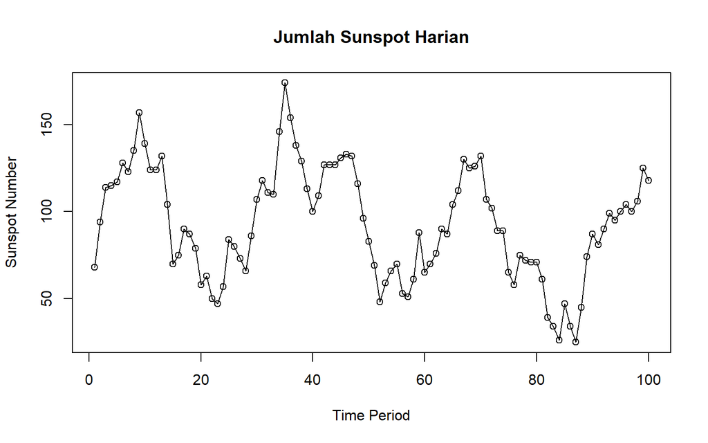

```r
ts.plot(sunspot.ts, xlab="Time Period", ylab="Sunspot Number",
        main = "Jumlah Sunspot Harian")
points(sunspot.ts)
```

# Single Moving Average & Double Moving Average

## Pembagian Data

Pembagian data latih dan data uji dilakukan dengan perbandingan 80% data latih dan 20% data uji.

```r
n <- nrow(sunspot_data)

n_train <- floor(0.8 * n)

# bagi data
training_ma <- sunspot_data[1:n_train, ]
testing_ma  <- sunspot_data[(n_train+1):n, ]

# ubah ke time series
train_ma.ts <- ts(training_ma$Sunspot)
test_ma.ts  <- ts(testing_ma$Sunspot)
```

Eksplorasi data dilakukan pada keseluruhan data, data latih serta data uji menggunakan plot data deret waktu.

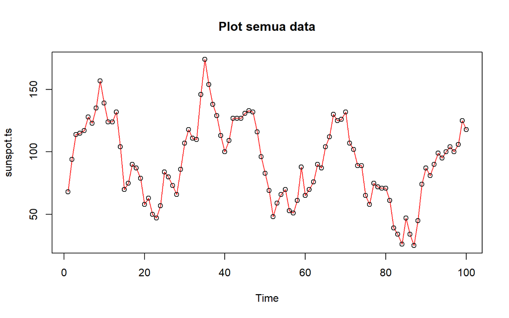

```r
#eksplorasi keseluruhan data
plot(sunspot.ts, col="red",main="Plot semua data")
points(sunspot.ts)
```

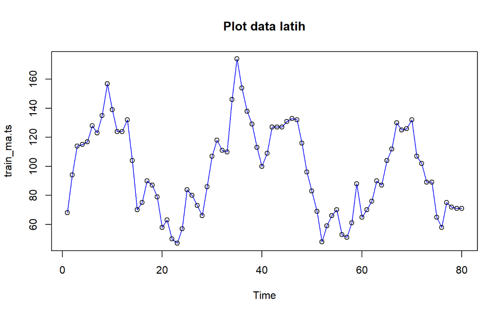

```r
#eksplorasi data latih
plot(train_ma.ts, col="blue",main="Plot data latih")
points(train_ma.ts)
```

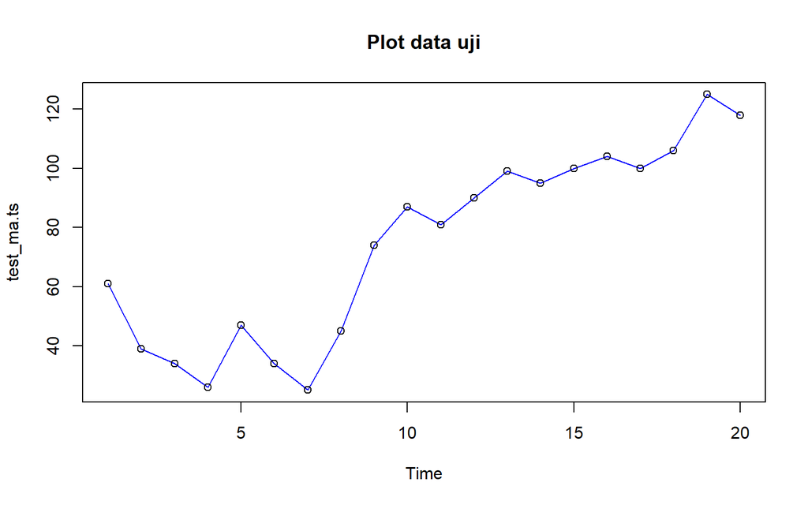

```r
#eksplorasi data uji
plot(test_ma.ts, col="blue",main="Plot data uji")
points(test_ma.ts)
```

Ketiga plot di atas menunjukkan pola fluktuasi yang serupa antara keseluruhan data, data latih, dan data uji, sehingga pembagian data dapat dikatakan cukup representatif terhadap karakteristik data secara umum.

```r
library(ggplot2)
```

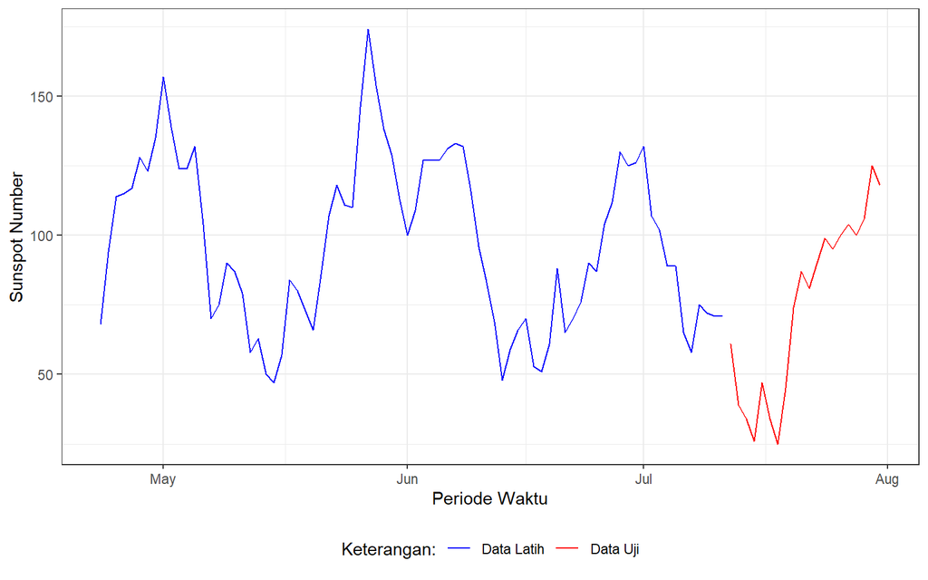

```r
ggplot() +
  geom_line(data = training_ma, aes(x = Tanggal, y = Sunspot, col = "Data Latih")) +
  geom_line(data = testing_ma, aes(x = Tanggal, y = Sunspot, col = "Data Uji")) +
  labs(x = "Periode Waktu", y = "Sunspot Number", color = "Legend") +
   scale_colour_manual(name="Keterangan:", breaks = c("Data Latih", "Data Uji"),
                      values = c("blue", "red")) +
  theme_bw() + theme(legend.position = "bottom",
                     plot.caption = element_text(hjust=0.5, size=12))
```

Plot gabungan berdasarkan tanggal ini memperjelas letak pembagian data latih (warna biru) dan data uji (warna merah) pada garis waktu yang sama, sehingga terlihat jelas bahwa data uji merupakan kelanjutan periode setelah data latih berakhir.

## Single Moving Average (SMA)

Pemulusan menggunakan metode SMA dilakukan dengan fungsi SMA(). Dalam hal ini akan dilakukan pemulusan dengan parameter N=3

```r
data.sma<-SMA(train_ma.ts, n=3)
data.sma
```

```
## Time Series:
## Start = 1
## End = 80
## Frequency = 1
##  [1]        NA        NA  92.00000 107.66667 115.33333 120.00000 122.66667
##  [8] 128.66667 138.33333 143.66667 140.00000 129.00000 126.66667 120.00000
## [15] 102.00000  83.00000  78.33333  84.00000  85.33333  74.66667  66.66667
## [22]  57.00000  53.33333  51.33333  62.66667  73.66667  79.00000  73.00000
## [29]  75.00000  86.33333 103.66667 112.00000 113.00000 122.33333 143.33333
## [36] 158.00000 155.33333 140.33333 126.66667 114.00000 107.33333 112.00000
## [43] 121.00000 127.00000 128.33333 130.33333 132.00000 127.00000 114.66667
## [50]  98.33333  82.66667  66.66667  58.66667  57.66667  65.00000  63.00000
## [57]  58.00000  55.00000  66.66667  71.33333  74.33333  70.33333  78.66667
## [64]  84.33333  93.66667 101.00000 115.33333 122.33333 127.00000 127.66667
## [71] 121.66667 113.66667  99.33333  93.33333  81.00000  70.66667  66.00000
## [78]  68.33333  72.66667  71.33333
```

```r
data.ramal<-c(NA,data.sma)
data.ramal
```

```
##  [1]        NA        NA        NA  92.00000 107.66667 115.33333 120.00000
##  [8] 122.66667 128.66667 138.33333 143.66667 140.00000 129.00000 126.66667
## [15] 120.00000 102.00000  83.00000  78.33333  84.00000  85.33333  74.66667
## [22]  66.66667  57.00000  53.33333  51.33333  62.66667  73.66667  79.00000
## [29]  73.00000  75.00000  86.33333 103.66667 112.00000 113.00000 122.33333
## [36] 143.33333 158.00000 155.33333 140.33333 126.66667 114.00000 107.33333
## [43] 112.00000 121.00000 127.00000 128.33333 130.33333 132.00000 127.00000
## [50] 114.66667  98.33333  82.66667  66.66667  58.66667  57.66667  65.00000
## [57]  63.00000  58.00000  55.00000  66.66667  71.33333  74.33333  70.33333
## [64]  78.66667  84.33333  93.66667 101.00000 115.33333 122.33333 127.00000
## [71] 127.66667 121.66667 113.66667  99.33333  93.33333  81.00000  70.66667
## [78]  66.00000  68.33333  72.66667  71.33333
```

Selanjutnya dilakukan peramalan sebanyak 20 periode sesuai dengan jumlah data uji. Pada metode SMA, seluruh hasil peramalan untuk 20 periode ke depan akan memiliki nilai yang sama dengan hasil ramalan satu periode ke depan.

```r
data.gab<-cbind(
  aktual=c(sunspot.ts),
  pemulusan=c(data.sma,rep(NA,20)),
  ramalan=c(data.ramal,rep(data.ramal[length(data.ramal)],19)))

data.gab
```

```
##        aktual pemulusan   ramalan
##   [1,]     68        NA        NA
##   [2,]     94        NA        NA
##   [3,]    114  92.00000        NA
##   [4,]    115 107.66667  92.00000
##   [5,]    117 115.33333 107.66667
##   [6,]    128 120.00000 115.33333
##   [7,]    123 122.66667 120.00000
##   [8,]    135 128.66667 122.66667
##   [9,]    157 138.33333 128.66667
##  [10,]    139 143.66667 138.33333
##  [11,]    124 140.00000 143.66667
##  [12,]    124 129.00000 140.00000
##  [13,]    132 126.66667 129.00000
##  [14,]    104 120.00000 126.66667
```

[output cut: 86 more lines]

Tabel di atas menggabungkan data aktual, hasil pemulusan pada periode data latih, serta hasil ramalan untuk 20 periode data uji. Karena SMA bersifat memulus data tanpa menangkap tren, seluruh nilai ramalan pada periode data uji bernilai konstan (sama dengan ramalan satu periode setelah data latih berakhir).

Adapun plot data deret waktu dari hasil peramalan yang dilakukan adalah sebagai berikut.

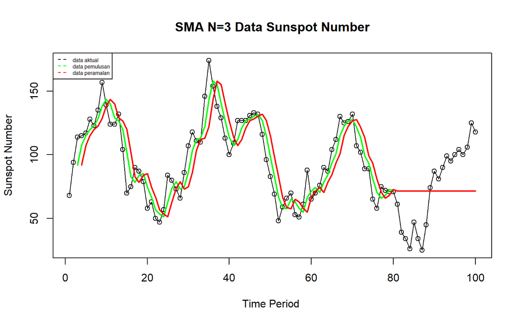

```r
ts.plot(sunspot.ts, xlab="Time Period ", ylab="Sunspot Number", main= "SMA N=3 Data Sunspot Number")
points(sunspot.ts)
lines(data.gab[,2],col="green",lwd=2)
lines(data.gab[,3],col="red",lwd=2)
legend("topleft",c("data aktual","data pemulusan","data peramalan"), lty=8, col=c("black","green","red"), cex=0.5)
```

Garis pemulusan (hijau) mengikuti pola data aktual dengan fluktuasi yang lebih halus, sedangkan garis ramalan (merah) pada bagian data uji tampak datar (konstan), sesuai karakteristik SMA yang tidak dapat memproyeksikan tren atau perubahan pola pada data.

### Akurasi Data Latih

```r
error_train.sma = train_ma.ts-data.ramal[1:length(train_ma.ts)]

SSE_train.sma = sum(error_train.sma[5:length(train_ma.ts)]^2)
MSE_train.sma = mean(error_train.sma[5:length(train_ma.ts)]^2)
MAPE_train.sma = mean(abs((error_train.sma[5:length(train_ma.ts)]/train_ma.ts[5:length(train_ma.ts)])*100))

akurasi_train.sma <- matrix(c(SSE_train.sma, MSE_train.sma, MAPE_train.sma))
row.names(akurasi_train.sma)<- c("SSE", "MSE", "MAPE")
colnames(akurasi_train.sma) <- c("Akurasi m = 3")
akurasi_train.sma
```

```
##      Akurasi m = 3
## SSE    28975.33333
## MSE      381.25439
## MAPE      17.50833
```

Nilai MAPE data latih pada metode pemulusan SMA dapat dilihat pada output di atas. Secara umum, berdasarkan output di atas, MAPE data latih SMA (N=3) sebesar 17,51%, nilai ini tergolong baik, namun belum masuk kategori sangat baik karena berada di atas ambang batas 10%. Selanjutnya dilakukan perhitungan nilai MAPE data uji pada metode pemulusan SMA.

### Akurasi Data Uji

```r
#Menghitung nilai keakuratan data uji
error_test.sma = test_ma.ts-data.gab[(n_train+1):n,3]

SSE_test.sma = sum(error_test.sma^2)
MSE_test.sma = mean(error_test.sma^2)
MAPE_test.sma = mean(abs((error_test.sma/test_ma.ts*100)))

akurasi_test.sma <- matrix(c(SSE_test.sma, MSE_test.sma, MAPE_test.sma))
row.names(akurasi_test.sma)<- c("SSE", "MSE", "MAPE")
colnames(akurasi_test.sma) <- c("Akurasi m = 3")
akurasi_test.sma
```

```
##      Akurasi m = 3
## SSE    20417.55556
## MSE     1020.87778
## MAPE      55.02558
```

Berdasarkan output di atas, MAPE data uji SMA (N=3) sebesar **55,03%**, jauh lebih besar dibandingkan MAPE data latih (17,51%), sehingga tergolong **tidak akurat** (di atas ambang batas 50%). hal ini menunjukkan SMA menghasilkan ramalan konstan untuk seluruh periode ke depan, sehingga begitu data aktual terus berfluktuasi menjauhi nilai konstan tersebut, kesalahan ramalan menjadi semakin besar dan menunjukkan SMA kurang mampu menggeneralisasi pola data sunspot untuk peramalan jangka menengah.

## Double Moving Average

```r
dma <- SMA(data.sma, n = 3)
At <- 2*data.sma - dma
Bt <- 2/(3-1)*(data.sma - dma)
data.dma<- At+Bt
data.ramal2<- c(NA, data.dma)

t = 1:20
f = c()

for (i in t) {
  f[i] = At[length(At)] + Bt[length(Bt)]*(i)
}

data.gab2 <- cbind(aktual = c(sunspot.ts),
                   pemulusan1 = c(data.sma,rep(NA,20)),
                   pemulusan2 = c(dma, rep(NA,20)),
                   At = c(At, rep(NA,20)),
                   Bt = c(Bt,rep(NA,20)),
                   ramalan = c(data.ramal2, f[-1]))
data.gab2
```

```
##        aktual pemulusan1 pemulusan2        At            Bt   ramalan
##   [1,]     68         NA         NA        NA            NA        NA
##   [2,]     94         NA         NA        NA            NA        NA
##   [3,]    114   92.00000         NA        NA            NA        NA
##   [4,]    115  107.66667         NA        NA            NA        NA
##   [5,]    117  115.33333  105.00000 125.66667  1.033333e+01        NA
##   [6,]    128  120.00000  114.33333 125.66667  5.666667e+00 136.00000
##   [7,]    123  122.66667  119.33333 126.00000  3.333333e+00 131.33333
##   [8,]    135  128.66667  123.77778 133.55556  4.888889e+00 129.33333
##   [9,]    157  138.33333  129.88889 146.77778  8.444444e+00 138.44444
##  [10,]    139  143.66667  136.88889 150.44444  6.777778e+00 155.22222
##  [11,]    124  140.00000  140.66667 139.33333 -6.666667e-01 157.22222
##  [12,]    124  129.00000  137.55556 120.44444 -8.555556e+00 138.66667
##  [13,]    132  126.66667  131.88889 121.44444 -5.222222e+00 111.88889
##  [14,]    104  120.00000  125.22222 114.77778 -5.222222e+00 116.22222
```

[output cut: 86 more lines]

Hasil pemulusan menggunakan metode DMA divisualisasikan sebagai berikut

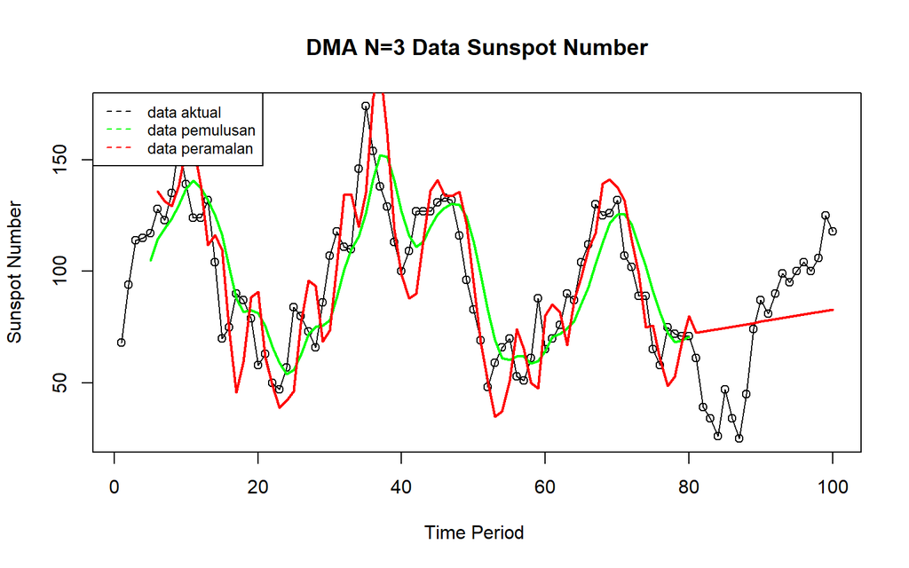

```r
ts.plot(sunspot.ts, xlab="Time Period ", ylab="Sunspot Number", main= "DMA N=3 Data Sunspot Number")
points(sunspot.ts)
lines(data.gab2[,3],col="green",lwd=2)
lines(data.gab2[,6],col="red",lwd=2)
legend("topleft",c("data aktual","data pemulusan","data peramalan"), lty=8, col=c("black","green","red"), cex=0.8)
```

Berbeda dengan plot SMA sebelumnya, garis ramalan (merah) pada DMA memiliki kemiringan (tidak datar) pada bagian data uji karena metode ini memproyeksikan tren yang teridentifikasi dari data latih.

### Akurasi Data Latih

```r
error_train.dma = train_ma.ts-data.ramal2[1:length(train_ma.ts)]

SSE_train.dma = sum(error_train.dma[8:length(train_ma.ts)]^2)
MSE_train.dma = mean(error_train.dma[8:length(train_ma.ts)]^2)
MAPE_train.dma = mean(abs((error_train.dma[8:length(train_ma.ts)]/train_ma.ts[8:length(train_ma.ts)])*100))

akurasi_train.dma <- matrix(c(SSE_train.dma, MSE_train.dma, MAPE_train.dma))
row.names(akurasi_train.dma)<- c("SSE", "MSE", "MAPE")
colnames(akurasi_train.dma) <- c("Akurasi m = 3")
akurasi_train.dma
```

```
##      Akurasi m = 3
## SSE    32022.62963
## MSE      438.66616
## MAPE      18.83612
```

Berdasarkan output di atas, MAPE data latih DMA (m=3) sebesar **18,84%**, sedikit lebih tinggi dibandingkan MAPE data latih SMA (17,51%), namun masih dalam kategori **baik** karena belum melewati ambang batas 20%. nilai SSE (32022,63) dan MSE (438,67) pada DMA juga sedikit lebih besar dibandingkan SMA, sehingga pada data latih ini metode SMA sedikit lebih baik dibandingkan DMA untuk data sunspot ini.

### Akurasi Data Uji

```r
error_test.dma = test_ma.ts-data.gab2[(n_train+1):n,6]
SSE_test.dma = sum(error_test.dma^2)
MSE_test.dma = mean(error_test.dma^2)
MAPE_test.dma = mean(abs((error_test.dma/test_ma.ts*100)))

akurasi_test.dma <- matrix(c(SSE_test.dma, MSE_test.dma, MAPE_test.dma))
row.names(akurasi_test.dma)<- c("SSE", "MSE", "MAPE")
colnames(akurasi_test.dma) <- c("Akurasi m = 3")
akurasi_test.dma
```

```
##      Akurasi m = 3
## SSE    16957.67901
## MSE      847.88395
## MAPE      53.74669
```

Berdasarkan data uji, MAPE DMA (53,75%) sedikit lebih rendah dibandingkan MAPE SMA (55,03%), begitu juga SSE dan MSE-nya yang lebih kecil, sehingga DMA sedikit lebih baik dibandingkan SMA dalam meramalkan data sunspot. Namun keduanya masih tergolong **tidak akurat** karena MAPE sama-sama di atas 50%, menunjukkan metode moving average kurang mampu menangkap fluktuasi data sunspot untuk peramalan 20 periode ke depan.

# Single Exponential Smoothing & Double Exponential Smoothing

## Pembagian Data

Pembagian data latih dan data uji dilakukan dengan perbandingan 80% data latih dan 20% data uji.

```r
# jumlah baris data
n <- nrow(sunspot_data)

# hitung batas 80%
n_train <- floor(0.8 * n)

# bagi data
training <- sunspot_data[1:n_train, ]
testing  <- sunspot_data[(n_train+1):n, ]

# ubah ke time series
train.ts <- ts(training$Sunspot)
test.ts  <- ts(testing$Sunspot)
```

Sama seperti pada bagian SMA/DMA, pembagian data dilakukan secara berurutan dengan 80% data pertama sebagai data latih dan 20% data sisanya sebagai data uji, agar model dapat divalidasi pada periode yang belum pernah “dilihat” saat pelatihan.

## Single Exponential Smoothing

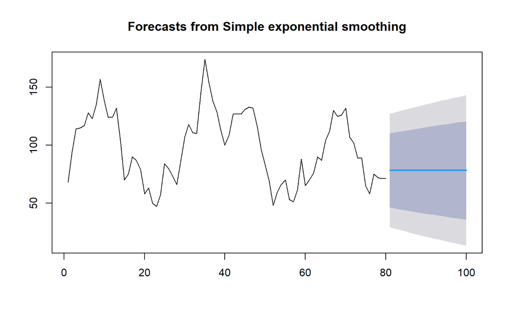

```r
#Cara 1 (fungsi ses)
ses.1 <- ses(train.ts, h = 20, alpha = 0.2)
plot(ses.1)
```

```r
ses.1
```

```
##     Point Forecast    Lo 80    Hi 80    Lo 95    Hi 95
##  81       78.20776 46.21659 110.1989 29.28148 127.1340
##  82       78.20776 45.58304 110.8325 28.31255 128.1030
##  83       78.20776 44.96156 111.4540 27.36208 129.0534
##  84       78.20776 44.35148 112.0640 26.42905 129.9865
##  85       78.20776 43.75221 112.6633 25.51254 130.9030
##  86       78.20776 43.16318 113.2523 24.61170 131.8038
##  87       78.20776 42.58390 113.8316 23.72576 132.6898
##  88       78.20776 42.01388 114.4016 22.85399 133.5615
##  89       78.20776 41.45270 114.9628 21.99574 134.4198
##  90       78.20776 40.89996 115.5156 21.15040 135.2651
##  91       78.20776 40.35529 116.0602 20.31740 136.0981
##  92       78.20776 39.81835 116.5972 19.49622 136.9193
##  93       78.20776 39.28882 117.1267 18.68637 137.7292
##  94       78.20776 38.76639 117.6491 17.88739 138.5281
##  95       78.20776 38.25080 118.1647 17.09885 139.3167
##  96       78.20776 37.74177 118.6738 16.32037 140.0952
##  97       78.20776 37.23907 119.1765 15.55155 140.8640
##  98       78.20776 36.74246 119.6731 14.79205 141.6235
##  99       78.20776 36.25173 120.1638 14.04154 142.3740
## 100       78.20776 35.76667 120.6489 13.29971 143.1158
```

Dengan alpha=0.2, bobot data terbaru relatif kecil sehingga hasil pemulusan cenderung lebih halus (kurang responsif terhadap perubahan mendadak pada data).

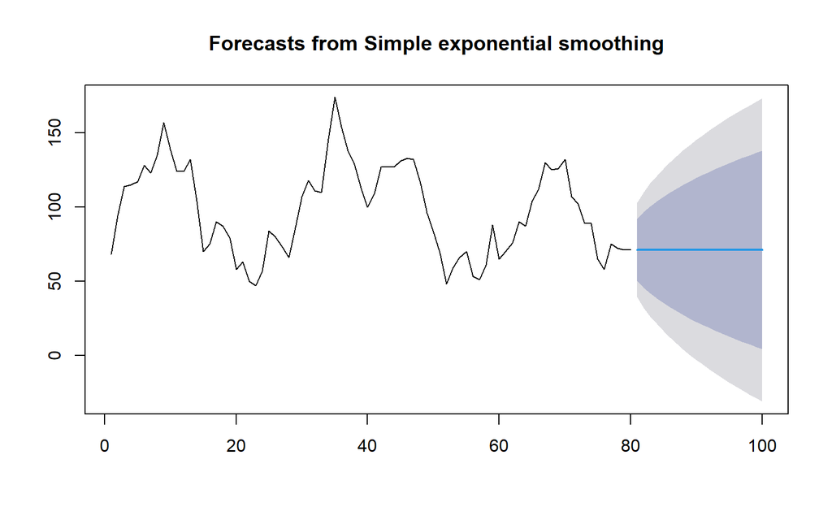

```r
ses.2<- ses(train.ts, h = 20, alpha = 0.7)
plot(ses.2)
```

```r
ses.2
```

```
##     Point Forecast     Lo 80     Hi 80      Lo 95    Hi 95
##  81       71.06889 50.219208  91.91858  39.182052 102.9557
##  82       71.06889 45.618609  96.51918  32.146043 109.9917
##  83       71.06889 41.730786 100.40700  26.200130 115.9377
##  84       71.06889 38.301041 103.83675  20.954788 121.1830
##  85       71.06889 35.197739 106.94005  16.208697 125.9291
##  86       71.06889 32.342322 109.79546  11.841714 130.2961
##  87       71.06889 29.683450 112.45434   7.775320 134.3625
##  88       71.06889 27.185383 114.95240   3.954855 138.1829
##  89       71.06889 24.822055 117.31573   0.340457 141.7973
##  90       71.06889 22.573763 119.56402  -3.098009 145.2358
##  91       71.06889 20.425184 121.71260  -6.383976 148.5218
##  92       71.06889 18.364123 123.77366  -9.536098 151.6739
##  93       71.06889 16.380682 125.75711 -12.569508 154.7073
##  94       71.06889 14.466702 127.67108 -15.496688 157.6345
##  95       71.06889 12.615359 129.52243 -18.328073 160.4659
##  96       71.06889 10.820879 131.31691 -21.072493 163.2103
##  97       71.06889  9.078323 133.05946 -23.737503 165.8753
##  98       71.06889  7.383429 134.75436 -26.329620 168.4674
##  99       71.06889  5.732487 136.40530 -28.854517 170.9923
## 100       71.06889  4.122246 138.01554 -31.317169 173.4550
```

Dengan alpha=0.7, bobot data terbaru jauh lebih besar sehingga hasil pemulusan lebih cepat mengikuti perubahan (fluktuasi) pada data aktual dibandingkan dengan alpha=0.2. Untuk metode SES, nilai ramalan pada seluruh periode ke depan bersifat konstan karena model ini tidak memperhitungkan komponen tren.

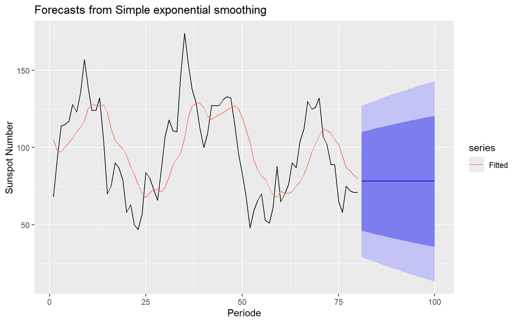

```r
autoplot(ses.1) +
  autolayer(fitted(ses.1), series="Fitted") +
  ylab("Sunspot Number") + xlab("Periode")
```

Garis “Fitted” pada plot di atas menunjukkan seberapa dekat hasil pemulusan SES (alpha=0.2) mengikuti data aktual pada periode data latih.

Selanjutnya akan digunakan fungsi HoltWinters() dengan nilai inisialisasi parameter dan panjang periode peramalan yang sama dengan fungsi ses().

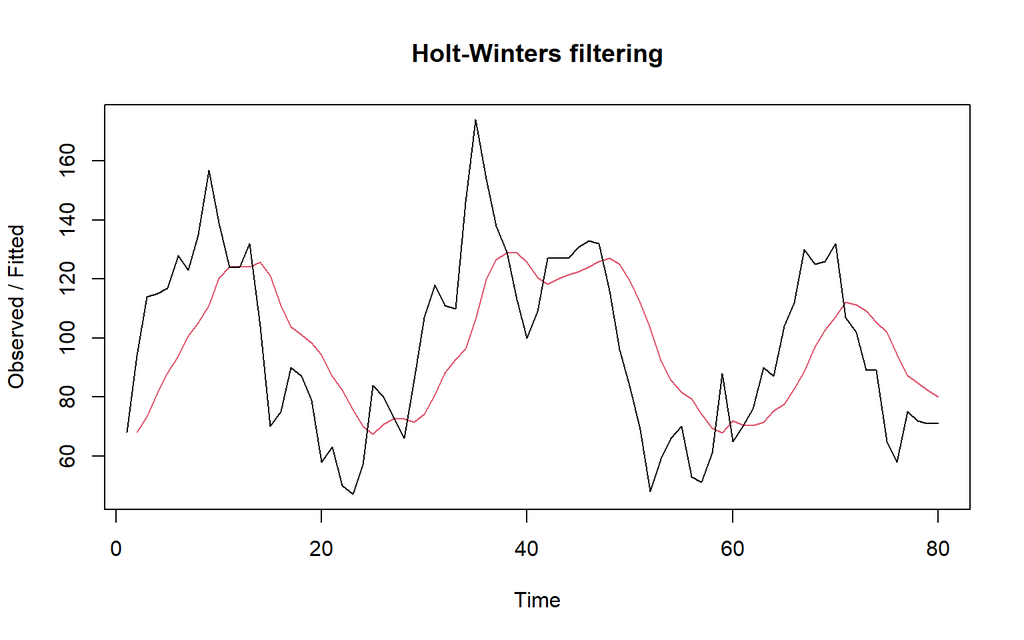

```r
ses1<- HoltWinters(train.ts, gamma = FALSE, beta = FALSE, alpha = 0.2)
plot(ses1)
```

```r
ramalan1<- forecast(ses1, h=20)
ramalan1
```

```
##     Point Forecast    Lo 80    Hi 80    Lo 95    Hi 95
##  81       78.20776 44.98942 111.4261 27.40469 129.0108
##  82       78.20776 44.33157 112.0840 26.39859 130.0169
##  83       78.20776 43.68625 112.7293 25.41166 131.0039
##  84       78.20776 43.05277 113.3627 24.44285 131.9727
##  85       78.20776 42.43051 113.9850 23.49118 132.9243
##  86       78.20776 41.81889 114.5966 22.55579 133.8597
##  87       78.20776 41.21738 115.1981 21.63586 134.7797
##  88       78.20776 40.62550 115.7900 20.73065 135.6849
##  89       78.20776 40.04279 116.3727 19.83948 136.5760
##  90       78.20776 39.46885 116.9467 18.96171 137.4538
##  91       78.20776 38.90329 117.5122 18.09676 138.3188
##  92       78.20776 38.34575 118.0698 17.24408 139.1714
##  93       78.20776 37.79591 118.6196 16.40316 140.0124
##  94       78.20776 37.25344 119.1621 15.57353 140.8420
##  95       78.20776 36.71807 119.6975 14.75475 141.6608
##  96       78.20776 36.18951 120.2260 13.94640 142.4691
##  97       78.20776 35.66753 120.7480 13.14809 143.2674
##  98       78.20776 35.15187 121.2637 12.35946 144.0561
##  99       78.20776 34.64232 121.7732 11.58016 144.8354
## 100       78.20776 34.13865 122.2769 10.80988 145.6056
```

Fungsi HoltWinters() dengan `beta = FALSE` dan `gamma = FALSE` menghasilkan model yang setara dengan SES sederhana (alpha = 0.2), dan output di atas memberikan hasil ramalan 20 periode ke depan beserta selang kepercayaannya.

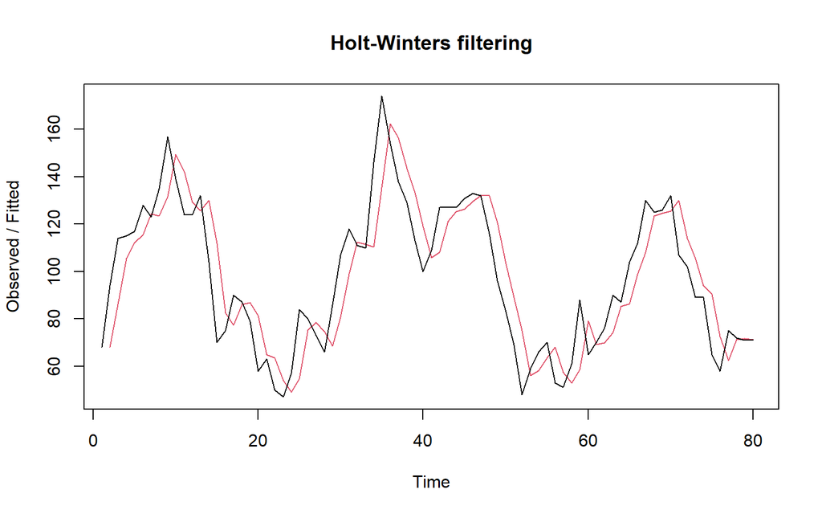

```r
ses2<- HoltWinters(train.ts, gamma = FALSE, beta = FALSE, alpha = 0.7)
plot(ses2)
```

```r
ramalan2<- forecast(ses2, h=20)
ramalan2
```

```
##     Point Forecast     Lo 80     Hi 80       Lo 95    Hi 95
##  81       71.06889 50.167509  91.97028  39.1029847 103.0348
##  82       71.06889 45.555503  96.58228  32.0495291 110.0883
##  83       71.06889 41.658039 100.47975  26.0888727 116.0489
##  84       71.06889 38.219790 103.91800  20.8305243 121.3073
##  85       71.06889 35.108792 107.02899  16.0726645 126.0651
##  86       71.06889 32.246295 109.89149  11.6948531 130.4429
##  87       71.06889 29.580830 112.55696   7.6183762 134.5194
##  88       71.06889 27.076569 115.06122   3.7884385 138.3493
##  89       71.06889 24.707380 117.43041   0.1650777 141.9727
##  90       71.06889 22.453514 119.68427  -3.2819139 145.4197
##  91       71.06889 20.299607 121.83818  -6.5760293 148.7138
##  92       71.06889 18.233435 123.90435  -9.7359671 151.8738
##  93       71.06889 16.245076 125.89271 -12.7768993 154.9147
##  94       71.06889 14.326351 127.81144 -15.7113372 157.8491
##  95       71.06889 12.470417 129.66737 -18.5497425 160.6875
##  96       71.06889 10.671487 131.46630 -21.3009684 163.4388
##  97       71.06889  8.924610 133.21318 -23.9725862 166.1104
##  98       71.06889  7.225513 134.91227 -26.5711307 168.7089
##  99       71.06889  5.570478 136.56731 -29.1022890 171.2401
## 100       71.06889  3.956244 138.18154 -31.5710464 173.7088
```

Output di atas memberikan hasil ramalan 20 periode ke depan (alpha = 0.7) beserta selang kepercayaannya.

Nilai parameter α dari kedua fungsi dapat dioptimalkan menyesuaikan dari error-nya paling minimumnya. Caranya adalah dengan membuat parameter α=NULL .

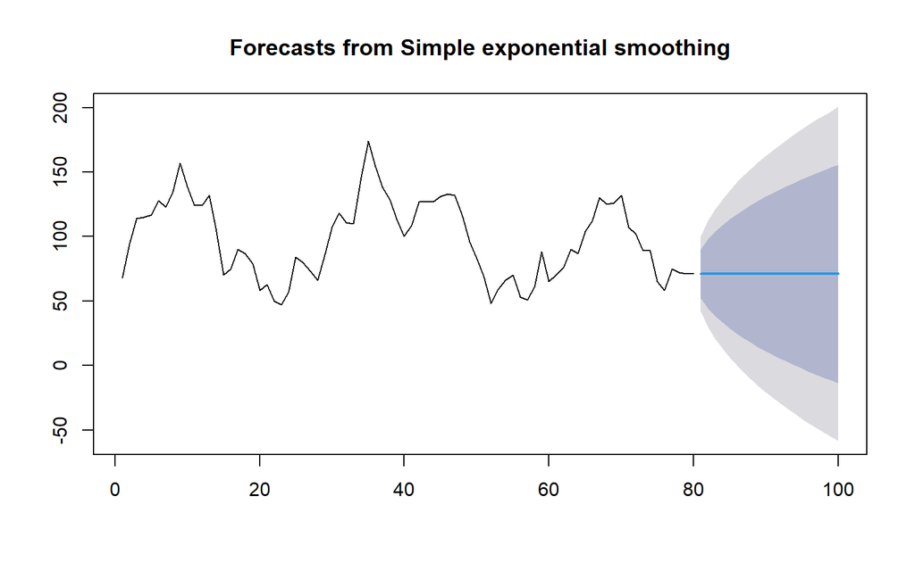

```r
ses.opt <- ses(train.ts, h = 20, alpha = NULL)
plot(ses.opt)
```

```r
ses.opt
```

```
##     Point Forecast       Lo 80     Hi 80        Lo 95     Hi 95
##  81             71  52.0548915  89.94511  42.02595681  99.97404
##  82             71  44.2089107  97.79109  30.02656472 111.97344
##  83             71  38.1882979 103.81170  20.81883204 121.18117
##  84             71  33.1126258 108.88737  13.05626144 128.94374
##  85             71  28.6408398 113.35916   6.21725494 135.78275
##  86             71  24.5980197 117.40198   0.03429506 141.96570
##  87             71  20.8802523 121.11975  -5.65153943 147.65154
##  88             71  17.4198317 124.58017 -10.94379608 152.94380
##  89             71  14.1697285 127.83027 -15.91440005 157.91440
##  90             71  11.0957006 130.90430 -20.61572003 162.61572
##  91             71   8.1718979 133.82810 -25.08729040 167.08729
##  92             71   5.3782372 136.62176 -29.35982561 171.35983
##  93             71   2.6987476 139.30125 -33.45775134 175.45775
##  94             71   0.1204797 141.87952 -37.40087193 179.40087
##  95             71  -2.3672388 144.36724 -41.20550902 183.20551
##  96             71  -4.7733268 146.77333 -44.88530310 186.88530
##  97             71  -7.1053288 149.10533 -48.45179235 190.45179
##  98             71  -9.3696940 151.36969 -51.91484009 193.91484
##  99             71 -11.5719871 153.57199 -55.28295663 197.28296
## 100             71 -13.7170489 155.71705 -58.56354562 200.56355
```

Nilai alpha optimum yang dihasilkan fungsi `ses()` merupakan nilai yang meminimumkan sum of squared errors (SSE) pada data latih, sehingga secara teori memberikan hasil pemulusan terbaik dibandingkan alpha yang ditentukan secara manual (0.2 maupun 0.7).

```r
#Lamda Optimum Holt Winter
HWopt<- HoltWinters(train.ts, gamma = FALSE, beta = FALSE,alpha = NULL)
HWopt
```

```
## Holt-Winters exponential smoothing without trend and without seasonal component.
##
## Call:
## HoltWinters(x = train.ts, alpha = NULL, beta = FALSE, gamma = FALSE)
##
## Smoothing parameters:
##  alpha: 0.9999371
##  beta : FALSE
##  gamma: FALSE
##
## Coefficients:
##   [,1]
## a   71
```

Nilai alpha optimum yang dihasilkan sebesar **0,9999371** (mendekati 1), artinya model memberi bobot yang sangat besar pada data terbaru dan hampir mengabaikan data lama, yang masuk akal untuk data sunspot yang fluktuatif. namun karena SES tetap menghasilkan ramalan konstan, nilai level akhir (a = 71) inilah yang menjadi ramalan untuk seluruh 20 periode ke depan.

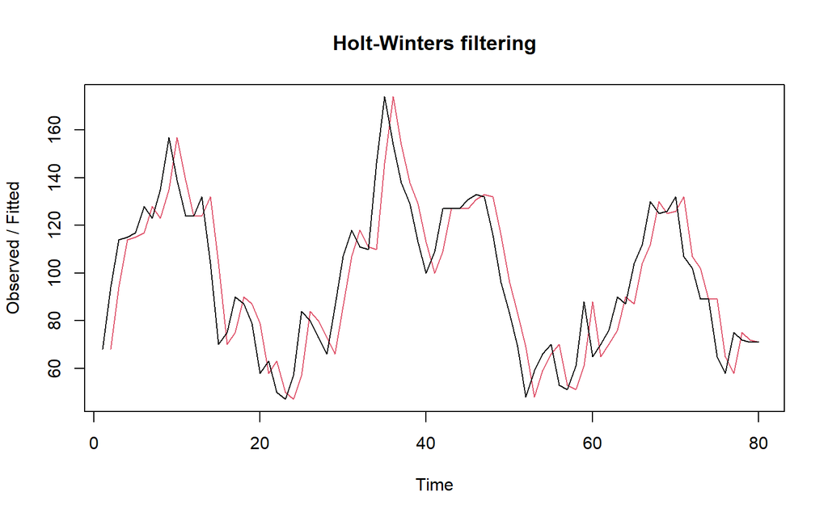

```r
plot(HWopt)
```

```r
ramalanopt<- forecast(HWopt, h=20)
ramalanopt
```

```
##     Point Forecast      Lo 80     Hi 80        Lo 95    Hi 95
##  81             71  52.055114  89.94489  42.02629720  99.9737
##  82             71  44.208728  97.79127  30.02628498 111.9737
##  83             71  38.187871 103.81213  20.81817868 121.1818
##  84             71  33.112015 108.88798  13.05532760 128.9447
##  85             71  28.640078 113.35992   6.21609052 135.7839
##  86             71  24.597128 117.40287   0.03293161 141.9671
##  87             71  20.879245 121.12075  -5.65307994 147.6531
##  88             71  17.418719 124.58128 -10.94549733 152.9455
##  89             71  14.168519 127.83148 -15.91624935 157.9162
##  90             71  11.094401 130.90560 -20.61770719 162.6177
##  91             71   8.170514 133.82949 -25.08940701 167.0894
##  92             71   5.376773 136.62323 -29.36206458 171.3621
##  93             71   2.697208 139.30279 -33.46010662 175.4601
##  94             71   0.118867 141.88113 -37.40333825 179.4033
##  95             71  -2.368921 144.36892 -41.20808176 183.2081
##  96             71  -4.775076 146.77508 -44.88797816 186.8880
##  97             71  -7.107142 149.10714 -48.45456605 190.4546
##  98             71  -9.371570 151.37157 -51.91770913 193.9177
##  99             71 -11.573923 153.57392 -55.28591801 197.2859
## 100             71 -13.719044 155.71904 -58.56659660 200.5666
```

Ramalan dengan parameter optimum ini menjadi acuan pembanding tambahan selain skenario alpha=0.2 dan alpha=0.7.

Setelah dilakukan peramalan, akan dilakukan perhitungan keakuratan hasil peramalan. Perhitungan akurasi ini dilakukan baik pada data latih dan data uji.

Perhitungan akurasi data dapat dilakukan dengan cara langsung maupun manual. Secara langsung, nilai akurasi dapat diambil dari objek yang tersimpan pada hasil SES, yaitu sum of squared errors (SSE). Nilai akurasi lain dapat dihitung pula dari nilai SSE tersebut.

### Akurasi Data Latih

```r
SSE1<-ses1$SSE
MSE1<-ses1$SSE/length(train.ts)
RMSE1<-sqrt(MSE1)

akurasi1 <- matrix(c(SSE1,MSE1,RMSE1))
row.names(akurasi1)<- c("SSE", "MSE", "RMSE")
colnames(akurasi1) <- c("Akurasi lamda=0.2")
akurasi1
```

```
##      Akurasi lamda=0.2
## SSE         52438.6470
## MSE           655.4831
## RMSE           25.6024
```

```r
SSE2<-ses2$SSE
MSE2<-ses2$SSE/length(train.ts)
RMSE2<-sqrt(MSE2)

akurasi2 <- matrix(c(SSE2,MSE2,RMSE2))
row.names(akurasi2)<- c("SSE", "MSE", "RMSE")
colnames(akurasi2) <- c("Akurasi lamda=0.7")
akurasi2
```

```
##      Akurasi lamda=0.7
## SSE        20748.06630
## MSE          259.35083
## RMSE          16.10437
```

Pada data latih, alpha=0.7 (SSE=20748,07; MSE=259,35; RMSE=16,10) jauh lebih unggul dibandingkan alpha=0.2 (SSE=52438,65; MSE=655,48; RMSE=25,60), nilai SSE dan MSE-nya kurang dari setengah nilai alpha=0.2. Hal ini masuk akal karena data sunspot berfluktuasi cepat dari hari ke hari, sehingga bobot yang lebih besar pada observasi terbaru (alpha besar) lebih mampu mengikuti perubahan tersebut saat pemulusan.

```r
SSE1<-ses1$SSE
SSE1
```

```
## [1] 52438.65
```

Nilai SSE di atas diambil langsung dari objek `ses1` sebagai pengecekan silang terhadap nilai SSE1 yang telah dihitung sebelumnya.

```r
fitted1<-ramalan1$fitted
sisaan1<-ramalan1$residuals
head(sisaan1)
```

```
## Time Series:
## Start = 1
## End = 6
## Frequency = 1
## [1]      NA 26.0000 40.8000 33.6400 28.9120 34.1296
```

`sisaan1` merupakan residual (selisih data aktual dan hasil pemulusan) dari model dengan alpha=0.2, yang akan digunakan untuk menghitung ukuran akurasi seperti SSE, MSE, dan MAPE secara manual.

```r
resid1<-training$Sunspot-ramalan1$fitted
head(resid1)
```

```
## Time Series:
## Start = 1
## End = 6
## Frequency = 1
## [1]      NA 26.0000 40.8000 33.6400 28.9120 34.1296
```

Perhitungan manual `resid1` ini menghasilkan nilai yang sama dengan `sisaan1`, sebagai verifikasi bahwa residual dari fungsi `forecast()` dihitung dengan cara yang konsisten.

```r
SSE.1=sum(sisaan1[2:length(train.ts)]^2)
SSE.1
```

```
## [1] 52438.65
```

```r
MSE.1 = SSE.1/length(train.ts)
MSE.1
```

```
## [1] 655.4831
```

```r
MAPE.1 = sum(abs(sisaan1[2:length(train.ts)]/train.ts[2:length(train.ts)])*
               100)/length(train.ts)
MAPE.1
```

```
## [1] 24.44571
```

```r
akurasi.1 <- matrix(c(SSE.1,MSE.1,MAPE.1))
row.names(akurasi.1)<- c("SSE", "MSE", "MAPE")
colnames(akurasi.1) <- c("Akurasi lamda=0.2")
akurasi.1
```

```
##      Akurasi lamda=0.2
## SSE        52438.64700
## MSE          655.48309
## MAPE          24.44571
```

```r
fitted2<-ramalan2$fitted
sisaan2<-ramalan2$residuals
head(sisaan2)
```

```
## Time Series:
## Start = 1
## End = 6
## Frequency = 1
## [1]      NA 26.0000 27.8000  9.3400  4.8020 12.4406
```

Residual `sisaan2` dihitung dengan cara yang sama seperti `sisaan1`, namun berasal dari model dengan alpha=0.7.

```r
resid2<-training$Sunspot-ramalan2$fitted
head(resid2)
```

```
## Time Series:
## Start = 1
## End = 6
## Frequency = 1
## [1]      NA 26.0000 27.8000  9.3400  4.8020 12.4406
```

```r
SSE.2=sum(sisaan2[2:length(train.ts)]^2)
SSE.2
```

```
## [1] 20748.07
```

```r
MSE.2 = SSE.2/length(train.ts)
MSE.2
```

```
## [1] 259.3508
```

```r
MAPE.2 = sum(abs(sisaan2[2:length(train.ts)]/train.ts[2:length(train.ts)])*
               100)/length(train.ts)
MAPE.2
```

```
## [1] 14.09195
```

```r
akurasi.2 <- matrix(c(SSE.2,MSE.2,MAPE.2))
row.names(akurasi.2)<- c("SSE", "MSE", "MAPE")
colnames(akurasi.2) <- c("Akurasi lamda=0.7")
akurasi.2
```

```
##      Akurasi lamda=0.7
## SSE        20748.06630
## MSE          259.35083
## MAPE          14.09195
```

Dari sisi MAPE, alpha=0.7 menghasilkan MAPE data latih sebesar 14,09%, jauh lebih baik dibandingkan alpha=0.2 (MAPE=24,45%). Kedua nilai ini belum masuk kategori “sangat baik” (MAPE di bawah 10%), namun MAPE alpha=0.7 sudah cukup mendekati ambang tersebut, sehingga pada data latih SES dengan alpha besar (0.7) jelas lebih unggul dibandingkan alpha kecil (0.2) untuk data sunspot ini.

### Akurasi Data Uji

Akurasi data uji dapat dihitung dengan cara yang hampir sama dengan perhitungan akurasi data latih.

```r
n_test <- nrow(testing)

# error (ramalan - aktual), samakan panjang dan tipe numeric
e1   <- as.numeric(ramalan1$mean)[1:n_test] - as.numeric(testing$Sunspot)
e2   <- as.numeric(ramalan2$mean)[1:n_test] - as.numeric(testing$Sunspot)
eopt <- as.numeric(ramalanopt$mean)[1:n_test] - as.numeric(testing$Sunspot)

# SSE / MSE / RMSE untuk masing-masing model (abaikan NA)
SSEtesting1  <- sum(e1^2,  na.rm = TRUE)
MSEtesting1  <- mean(e1^2, na.rm = TRUE)
RMSEtesting1 <- sqrt(MSEtesting1)

SSEtesting2  <- sum(e2^2,  na.rm = TRUE)
MSEtesting2  <- mean(e2^2, na.rm = TRUE)
RMSEtesting2 <- sqrt(MSEtesting2)

SSEtestingopt  <- sum(eopt^2,  na.rm = TRUE)
MSEtestingopt  <- mean(eopt^2, na.rm = TRUE)
RMSEtestingopt <- sqrt(MSEtestingopt)

# Tabel ringkas
akurasitesting_SSE <- matrix(c(SSEtesting1, SSEtesting2, SSEtestingopt),
                             nrow = 3,
                             dimnames = list(c("SSE1","SSE2","SSEopt"), "Nilai"))
akurasitesting_MSE <- matrix(c(MSEtesting1, MSEtesting2, MSEtestingopt),
                             nrow = 3,
                             dimnames = list(c("MSE1","MSE2","MSEopt"), "Nilai"))
akurasitesting_RMSE <- matrix(c(RMSEtesting1, RMSEtesting2, RMSEtestingopt),
                              nrow = 3,
                              dimnames = list(c("RMSE1","RMSE2","RMSEopt"), "Nilai"))

akurasitesting_SSE
```

```
##           Nilai
## SSE1   20491.95
## SSE2   20452.45
## SSEopt 20462.00
```

```r
akurasitesting_MSE
```

```
##           Nilai
## MSE1   1024.597
## MSE2   1022.622
## MSEopt 1023.100
```

```r
akurasitesting_RMSE
```

```
##            Nilai
## RMSE1   32.00933
## RMSE2   31.97847
## RMSEopt 31.98593
```

```r
accuracy(ramalan1, testing$Sunspot)
```

```
##                      ME     RMSE      MAE        MPE     MAPE     MASE
## Training set  0.6460609 25.76393 21.53327  -6.383792 24.75515 1.839057
## Test set     -3.7077616 32.00933 28.17922 -35.860240 58.96962 2.406658
##                   ACF1
## Training set 0.8213157
## Test set            NA
```

```r
accuracy(ramalan2, testing$Sunspot)
```

```
##                      ME     RMSE      MAE        MPE     MAPE     MASE
## Training set 0.05549536 16.20598 12.81936  -2.046676 14.27033 1.094842
## Test set     3.43110645 31.97847 29.18622 -23.458807 54.89573 2.492661
##                   ACF1
## Training set 0.4475247
## Test set            NA
```

```r
accuracy(ramalanopt, testing$Sunspot)
```

```
##                      ME     RMSE      MAE        MPE     MAPE     MASE    ACF1
## Training set 0.03797707 14.68896 11.70902  -1.329806 13.08199 1.000014 0.22562
## Test set     3.50000000 31.98593 29.20000 -23.339127 54.86190 2.493838      NA
```

Fungsi `accuracy()` memberikan ukuran-ukuran akurasi standar (seperti RMSE dan MAPE) untuk data uji, dan hasilnya konsisten dengan perhitungan manual `akurasitesting_SSE`, `akurasitesting_MSE`, dan `akurasitesting_RMSE` di atas. Pada data uji ketiga skenario justru memberikan MSE yang hampir sama (alpha=0.2: 1024,60; alpha=0.7: 1022,62; alpha optimum: 1023,10), berbeda jauh dengan pola pada data latih, di mana alpha=0.7 tampak jauh lebih unggul. Ini terjadi karena SES tetap menghasilkan ramalan konstan untuk semua 20 periode ke depan (nilai level terakhir), hasil akhirnya di data uji hanya bergantung pada level pada akhir data latih, yang ternyata mirip untuk ketiga skenario. Selain itu, MAPE data uji kedua skenario yang dihitung `accuracy()` juga masih tinggi (58,97% untuk alpha=0.2 dan 54,90% untuk alpha=0.7), sehingga sama seperti SMA/DMA, metode SES juga tergolong tidak akurat (MAPE jauh di atas 10%) dalam meramalkan 20 periode ke depan data sunspot ini.

## Double Exponential Smoothing

Pemulusan dengan metode DES kali ini akan menggunakan fungsi HoltWinters() . Jika sebelumnya nilai argumen beta dibuat FALSE , kali ini argumen tersebut akan diinisialisasi bersamaan dengan nilai alpha .

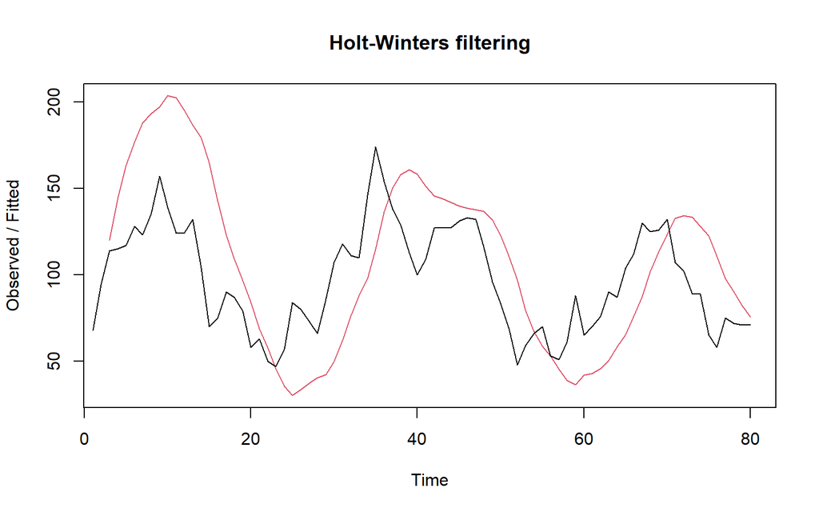

```r
des.1<- HoltWinters(train.ts, gamma = FALSE, beta = 0.2, alpha = 0.2)
plot(des.1)
```

```r
ramalandes1<- forecast(des.1, h=20)
ramalandes1
```

```
##     Point Forecast       Lo 80    Hi 80       Lo 95    Hi 95
##  81      70.212581   20.993715 119.4314   -5.061178 145.4863
##  82      65.612747   14.996223 116.2293  -11.798546 143.0240
##  83      61.012914    8.553822 113.4720  -19.216343 141.2422
##  84      56.413080    1.640643 111.1855  -27.354134 140.1803
##  85      51.813247   -5.753892 109.3804  -36.228095 139.8546
##  86      47.213414  -13.627157 108.0540  -45.834209 140.2610
##  87      42.613580  -21.966373 107.1935  -56.152935 141.3801
##  88      38.013747  -30.751896 106.7794  -67.154228 143.1817
##  89      33.413913  -39.960174 106.7880  -78.802070 145.6299
##  90      28.814080  -49.566094 107.1943  -91.058052 148.6862
##  91      24.214247  -59.544637 107.9731 -103.883911 152.3124
##  92      19.614413  -69.871928 109.1008 -117.243135 156.4720
##  93      15.014580  -80.525818 110.5550 -131.101850 161.1310
##  94      10.414746  -91.486137 112.3156 -145.429206 166.2587
##  95       5.814913 -102.734726 114.3646 -160.197434 171.8273
##  96       1.215079 -114.255358 116.6855 -175.381716 177.8119
##  97      -3.384754 -126.033585 119.2641 -190.959954 184.1904
##  98      -7.984587 -138.056556 122.0874 -206.912498 190.9433
##  99     -12.584421 -150.312843 125.1440 -223.221866 198.0530
## 100     -17.184254 -162.792260 128.4238 -239.872482 205.5040
```

Dengan alpha=0.2 dan beta=0.2, model DES pertama ini memberikan bobot rendah baik pada komponen level maupun tren, sehingga hasil pemulusan dan ramalannya relatif halus namun tetap dapat menangkap arah tren (naik/turun), berbeda dengan SES yang ramalannya konstan.

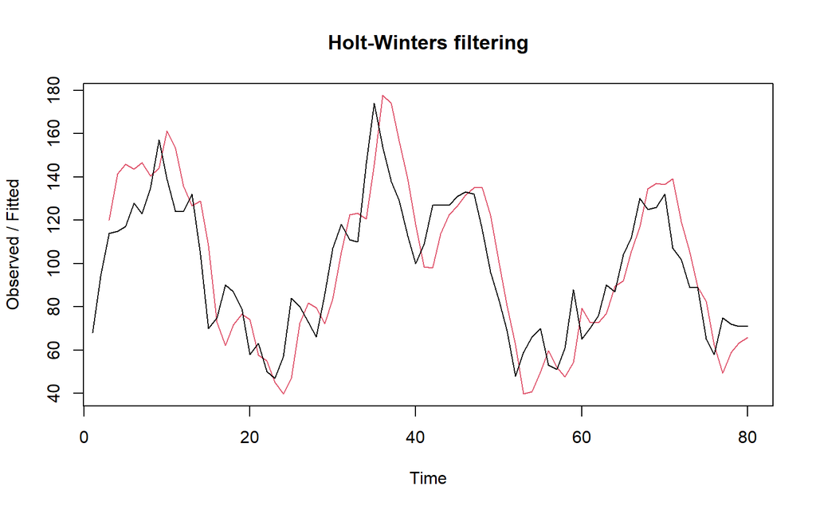

```r
des.2<- HoltWinters(train.ts, gamma = FALSE, beta = 0.3, alpha = 0.6)
plot(des.2)
```

```r
ramalandes2<- forecast(des.2, h=20)
ramalandes2
```

```
##     Point Forecast       Lo 80     Hi 80       Lo 95    Hi 95
##  81       67.78973   44.715888  90.86357   32.501334 103.0781
##  82       66.64321   37.380334  95.90608   21.889505 111.3969
##  83       65.49668   28.795489 102.19787    9.367052 121.6263
##  84       64.35016   19.196117 109.50420   -4.706989 133.4073
##  85       63.20363    8.737635 117.66963  -20.094923 146.5022
##  86       62.05711   -2.475440 126.58966  -36.636908 160.7511
##  87       60.91059  -14.369570 136.19074  -54.220477 176.0416
##  88       59.76406  -26.890427 146.41855  -72.762543 192.2907
##  89       58.61754  -39.996079 157.23115  -92.198975 209.4340
##  90       57.47101  -53.652955 168.59498 -112.478431 227.4205
##  91       56.32449  -67.833366 180.48234 -133.558564 246.2075
##  92       55.17797  -82.513919 192.86985 -155.403599 265.7595
##  93       54.03144  -97.674465 205.73735 -177.982720 286.0456
##  94       52.88492 -113.297373 219.06721 -201.268963 307.0388
##  95       51.73839 -129.367016 232.84380 -225.238429 328.7152
##  96       50.59187 -145.869397 247.05314 -249.869709 351.0534
##  97       49.44534 -162.791863 261.68255 -275.143455 374.0341
##  98       48.29882 -180.122893 276.72053 -301.042044 397.6397
##  99       47.15230 -197.851926 292.15652 -327.549327 421.8539
## 100       46.00577 -215.969229 307.98077 -354.650418 446.6620
```

Skenario kedua menggunakan alpha=0.6 dan beta=0.3 yang lebih besar, sehingga model lebih responsif terhadap perubahan level maupun tren terbaru dibandingkan skenario pertama.

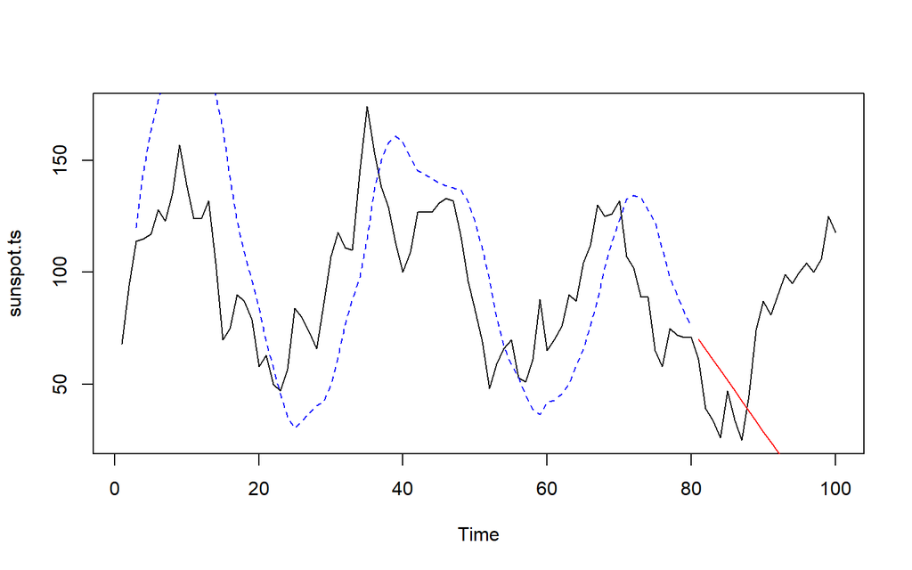

```r
plot(sunspot.ts)
lines(des.1$fitted[,1], lty=2, col="blue")
lines(ramalandes1$mean, col="red")
```

Plot di atas membandingkan data aktual dengan hasil pemulusan (garis putus-putus biru) dan hasil ramalan (garis merah) dari model DES pertama.

```r
des.opt<- HoltWinters(train.ts, gamma = FALSE)
des.opt
```

```
## Holt-Winters exponential smoothing with trend and without seasonal component.
##
## Call:
## HoltWinters(x = train.ts, gamma = FALSE)
##
## Smoothing parameters:
##  alpha: 1
##  beta : 0.2385493
##  gamma: FALSE
##
## Coefficients:
##        [,1]
## a 71.000000
## b -1.611265
```

Dengan alpha dan beta tidak ditentukan (dibiarkan dioptimasi), fungsi HoltWinters() mencari kombinasi alpha dan beta yang meminimumkan SSE pada data latih, sehingga menghasilkan model DES dengan parameter optimum.

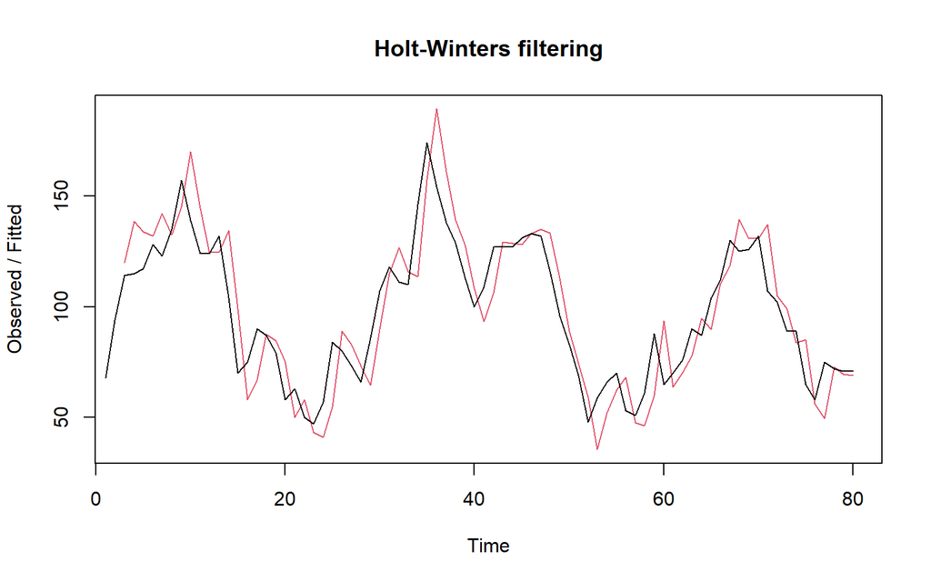

```r
plot(des.opt)
```

```r
ramalandesopt<- forecast(des.opt, h=20)
ramalandesopt
```

```
##     Point Forecast       Lo 80     Hi 80        Lo 95    Hi 95
##  81       69.38873   49.274379  89.50309   38.6264821 100.1510
##  82       67.77747   35.758319  99.79662   18.8084042 116.7465
##  83       66.16620   22.485971 109.84644   -0.6369485 132.9694
##  84       64.55494    8.887674 120.22221  -20.5807965 149.6907
##  85       62.94367   -5.202621 131.08997  -41.2770910 167.1644
##  86       61.33241  -19.841657 142.50647  -62.8126113 185.4774
##  87       59.72114  -35.046072 154.48836  -85.2128058 204.6551
##  88       58.10988  -50.815569 167.03533 -108.4772176 224.6970
##  89       56.49861  -67.142235 180.13946 -132.5937461 245.5910
##  90       54.88735  -84.014742 193.78944 -157.5450665 267.3198
##  91       53.27608 -101.420373 207.97254 -183.3117306 289.8639
##  92       51.66482 -119.346044 222.67568 -209.8737268 313.2034
##  93       50.05355 -137.778824 237.88593 -237.2112778 337.3184
##  94       48.44229 -156.706196 253.59077 -265.3052428 362.1898
##  95       46.83102 -176.116185 269.77823 -294.1373074 387.7994
##  96       45.21976 -195.997405 286.43692 -323.6900581 414.1296
##  97       43.60849 -216.339068 303.55605 -353.9469937 441.1640
##  98       41.99723 -237.130964 321.12542 -384.8925024 468.8870
##  99       40.38596 -258.363440 339.13536 -416.5118208 497.2837
## 100       38.77470 -280.027367 357.57676 -448.7909852 526.3404
```

Ramalan dari model optimum ini menjadi pembanding tambahan terhadap dua skenario parameter manual sebelumnya.

### Akurasi Data Latih

Selanjutnya akan dilakukan perhitungan akurasi pada data latih maupun data uji dengan ukuran akurasi SSE, MSE dan MAPE.

```r
ssedes.train1<-des.1$SSE
msedes.train1<-ssedes.train1/length(train.ts)
sisaandes1<-ramalandes1$residuals
head(sisaandes1)
```

```
## Time Series:
## Start = 1
## End = 6
## Frequency = 1
## [1]        NA        NA  -6.00000 -29.56000 -46.22560 -48.70906
```

```r
mapedes.train1 <- sum(abs(sisaandes1[3:length(train.ts)]/train.ts[3:length(train.ts)])
                      *100)/length(train.ts)

akurasides.1 <- matrix(c(ssedes.train1,msedes.train1,mapedes.train1))
row.names(akurasides.1)<- c("SSE", "MSE", "MAPE")
colnames(akurasides.1) <- c("Akurasi lamda=0.2 dan gamma=0.2")
akurasides.1
```

```
##      Akurasi lamda=0.2 dan gamma=0.2
## SSE                     121077.54321
## MSE                       1513.46929
## MAPE                        35.07464
```

```r
ssedes.train2<-des.2$SSE
msedes.train2<-ssedes.train2/length(train.ts)
sisaandes2<-ramalandes2$residuals
head(sisaandes2)
```

```
## Time Series:
## Start = 1
## End = 6
## Frequency = 1
## [1]        NA        NA  -6.00000 -26.32000 -28.71040 -15.49869
```

```r
mapedes.train2 <- sum(abs(sisaandes2[3:length(train.ts)]/train.ts[3:length(train.ts)])
                      *100)/length(train.ts)

akurasides.2 <- matrix(c(ssedes.train2,msedes.train2,mapedes.train2))
row.names(akurasides.2)<- c("SSE", "MSE", "MAPE")
colnames(akurasides.2) <- c("Akurasi lamda=0.6 dan gamma=0.3")
akurasides.2
```

```
##      Akurasi lamda=0.6 dan gamma=0.3
## SSE                       25252.3943
## MSE                         315.6549
## MAPE                         15.7674
```

Pada data latih, skenario 2 (alpha=0.6, beta=0.3) jauh lebih baik dibandingkan skenario 1 (alpha=0.2, beta=0.2): SSE=25252,39 dan MAPE=15,77% untuk skenario 2, dibandingkan SSE=121077,54 dan MAPE=35,07% untuk skenario 1. Bobot alpha dan beta yang lebih besar pada skenario 2 membuat model lebih cepat menyesuaikan diri dengan level maupun perubahan tren data yang fluktuatif ini.

```r
selisihdes1<-ramalandes1$mean-testing$Sunspot
selisihdes1
```

```
## Time Series:
## Start = 81
## End = 100
## Frequency = 1
##  [1]    9.212581   26.612747   27.012914   30.413080    4.813247   13.213414
##  [7]   17.613580   -6.986253  -40.586087  -58.185920  -56.785753  -70.385587
## [13]  -83.985420  -84.585254  -94.185087 -102.784921 -103.384754 -113.984587
## [19] -137.584421 -135.184254
```

### Akurasi Data Uji

```r
SSEtestingdes1<-sum(selisihdes1^2)
MSEtestingdes1<-SSEtestingdes1/length(testing$Sunspot)
MAPEtestingdes1<-sum(abs(selisihdes1/testing$Sunspot)*100)/length(testing$Sunspot)

selisihdes2<-ramalandes2$mean-testing$Sunspot
selisihdes2
```

```
## Time Series:
## Start = 81
## End = 100
## Frequency = 1
##  [1]   6.78973  27.64321  31.49668  38.35016  16.20363  28.05711  35.91059
##  [8]  14.76406 -15.38246 -29.52899 -24.67551 -34.82203 -44.96856 -42.11508
## [15] -48.26161 -53.40813 -50.55466 -57.70118 -77.84770 -71.99423
```

```r
SSEtestingdes2<-sum(selisihdes2^2)
MSEtestingdes2<-SSEtestingdes2/length(testing$Sunspot)
MAPEtestingdes2<-sum(abs(selisihdes2/testing$Sunspot)*100)/length(testing$Sunspot)

selisihdesopt<-ramalandesopt$mean-testing$Sunspot
selisihdesopt
```

```
## Time Series:
## Start = 81
## End = 100
## Frequency = 1
##  [1]   8.388735  28.777470  32.166205  38.554939  15.943674  27.332409
##  [7]  34.721144  13.109879 -17.501386 -32.112651 -27.723917 -38.335182
## [13] -48.946447 -46.557712 -53.168977 -58.780242 -56.391507 -64.002773
## [19] -84.614038 -79.225303
```

```r
SSEtestingdesopt<-sum(selisihdesopt^2)
MSEtestingdesopt<-SSEtestingdesopt/length(testing$Sunspot)
MAPEtestingdesopt<-sum(abs(selisihdesopt/testing$Sunspot)*100)/length(testing$Sunspot)

akurasitestingdes <-
  matrix(c(SSEtestingdes1,MSEtestingdes1,MAPEtestingdes1,SSEtestingdes2,MSEtestingdes2,
           MAPEtestingdes2,SSEtestingdesopt,MSEtestingdesopt,MAPEtestingdesopt),
         nrow=3,ncol=3)
row.names(akurasitestingdes)<- c("SSE", "MSE", "MAPE")
colnames(akurasitestingdes) <- c("des ske1","des ske2","des opt")
akurasitestingdes
```

```
##          des ske1   des ske2     des opt
## SSE  110745.09046 34866.4615 40932.04560
## MSE    5537.25452  1743.3231  2046.60228
## MAPE     74.36604    57.8565    60.49442
```

Tabel di atas merangkum akurasi data uji dari ketiga skenario DES. Skenario 2 (alpha=0.6, beta=0.3) memberikan hasil terbaik pada data uji (SSE=34866,46; MSE=1743,32; MAPE=57,86%), diikuti oleh model dengan parameter optimum (SSE=40932,05; MSE=2046,60; MAPE=60,49%), sedangkan skenario 1 (alpha=0.2, beta=0.2) memberikan hasil paling buruk (SSE=110745,09; MSE=5537,25; MAPE=74,37%). Cukup menarik bahwa parameter “optimum” — yang dipilih untuk meminimumkan SSE pada data latih — justru tidak menghasilkan performa terbaik pada data uji; ini adalah indikasi bahwa parameter tersebut overfit terhadap pola data latih dan kurang mampu digeneralisasi ke 20 periode data uji.

## Perbandingan SES dan DES

```r
MSEfull <-
  matrix(c(MSEtesting1,MSEtesting2,MSEtestingopt,MSEtestingdes1,MSEtestingdes2,
           MSEtestingdesopt),nrow=3,ncol=2)
row.names(MSEfull)<- c("ske 1", "ske 2", "ske opt")
colnames(MSEfull) <- c("ses","des")
MSEfull
```

```
##              ses      des
## ske 1   1024.597 5537.255
## ske 2   1022.622 1743.323
## ske opt 1023.100 2046.602
```

Tabel MSE di atas menunjukkan bahwa SES secara konsisten mengungguli DES pada data uji di ketiga skenario parameter yang sebanding: skenario 1 (SES=1024,60 vs DES=5537,25), skenario 2 (SES=1022,62 vs DES=1743,32), dan skenario optimum (SES=1023,10 vs DES=2046,60). Artinya, penambahan komponen tren pada DES justru merugikan akurasi peramalan out-of-sample untuk data ini, kemungkinan karena tren yang teridentifikasi dari data latih (yang cenderung menurun tajam di akhir periode latih) tidak berlanjut secara konsisten pada data uji, sehingga ekstrapolasi tren DES cenderung overshoot dan menghasilkan galat yang lebih besar dibandingkan SES yang ramalannya konstan.

# Pemulusan Data Musiman

```r
# Jumlah data
n <- nrow(sunspot_data)

# Menentukan jumlah data training 80%
n_train <- floor(0.8 * n)

# Membagi data menjadi training dan testing
training_winter <- sunspot_data[1:n_train, ]
testing_winter  <- sunspot_data[(n_train + 1):n, ]

# Mengubah data menjadi time series
# Frekuensi 7 digunakan untuk merepresentasikan pola mingguan
training_winter.ts <- ts(training_winter$Sunspot, frequency = 7)
testing_winter.ts  <- ts(testing_winter$Sunspot, frequency = 7)

# Jumlah data
length(training_winter.ts)
```

```
## [1] 80
```

```r
length(testing_winter.ts)
```

```
## [1] 20
```

Frekuensi musiman diset sebesar 7 untuk merepresentasikan pola mingguan. Jumlah bintik matahari (sunspot) secara fisik lebih dipengaruhi oleh siklus rotasi matahari (sekitar 27 hari) dan siklus aktivitas matahari 11 tahunan, bukan oleh pola mingguan; sehingga pemilihan frekuensi=7 di sini bersifat asumsi/latihan metode Winter dan sebaiknya dicek kembali apakah pola musiman mingguan benar-benar terlihat pada plot musiman berikut, atau apakah frekuensi lain (misalnya 27) lebih sesuai secara substansi.

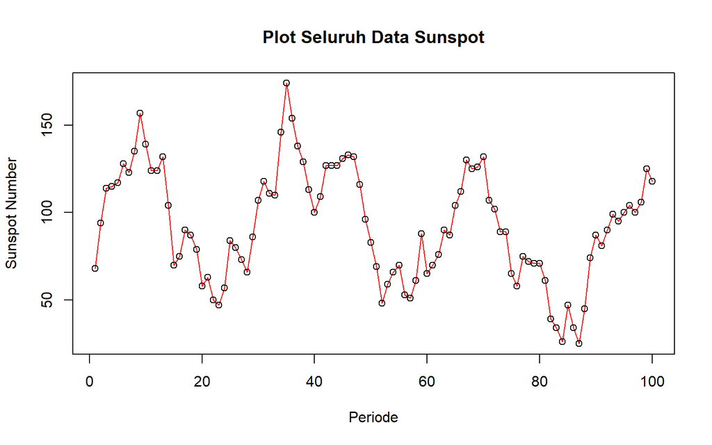

```r
# Plot seluruh data
plot(sunspot.ts,
     col = "red",
     main = "Plot Seluruh Data Sunspot",
     xlab = "Periode",
     ylab = "Sunspot Number")
points(sunspot.ts)
```

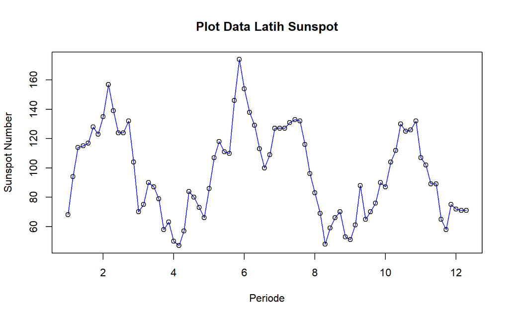

```r
# Plot data training
plot(training_winter.ts,
     col = "blue",
     main = "Plot Data Latih Sunspot",
     xlab = "Periode",
     ylab = "Sunspot Number")
points(training_winter.ts)
```

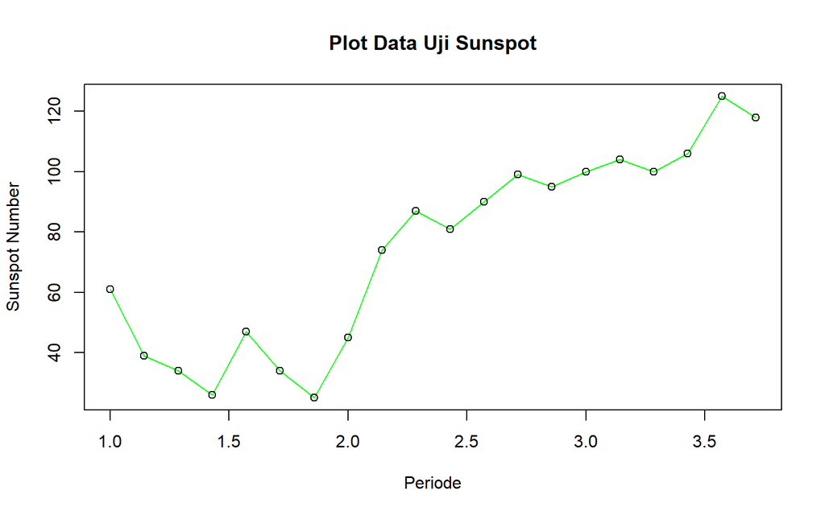

```r
# Plot data testing
plot(testing_winter.ts,
     col = "green",
     main = "Plot Data Uji Sunspot",
     xlab = "Periode",
     ylab = "Sunspot Number")
points(testing_winter.ts)
```

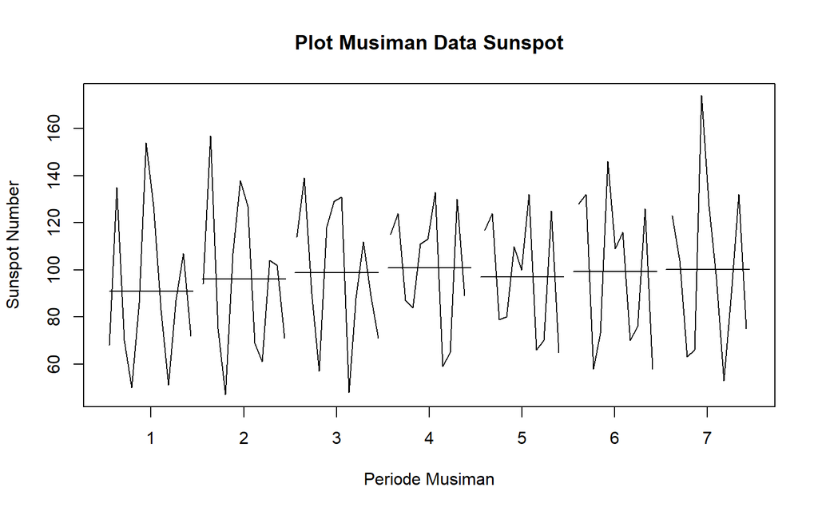

```r
# Plot seasonal
monthplot(training_winter.ts,
          main = "Plot Musiman Data Sunspot",
          ylab = "Sunspot Number",
          xlab = "Periode Musiman")
```

Plot musiman (monthplot) di atas menampilkan rata-rata dan variasi data pada tiap posisi dalam siklus 7 hari. Apabila garis rata-rata antarposisi relatif datar (tidak banyak berbeda), maka pola musiman mingguan tidak terlalu kuat pada data ini, dan hasil pemulusan Winter perlu dibandingkan hati-hati dengan metode non-musiman (SMA/DMA/SES/DES) sebelumnya.

## Winter Aditif

Pada model pertama digunakan nilai $\alpha=0.2$, $\beta=0.1$, dan $\gamma=0.1$. Selanjutnya dibandingkan dengan model Winter dengan parameter yang dioptimalkan secara otomatis.

### Pemulusan

```r
# Pemulusan Winter Aditif
winter1 <- HoltWinters(
  training_winter.ts,
  alpha = 0.2,
  beta = 0.1,
  gamma = 0.1,
  seasonal = "additive"
)

winter1
```

```
## Holt-Winters exponential smoothing with trend and additive seasonal component.
##
## Call:
## HoltWinters(x = training_winter.ts, alpha = 0.2, beta = 0.1,     gamma = 0.1, seasonal = "additive")
##
## Smoothing parameters:
##  alpha: 0.2
##  beta : 0.1
##  gamma: 0.1
##
## Coefficients:
##          [,1]
## a  78.0020227
## b  -1.6247395
## s1 -1.8039955
## s2 -5.3194048
## s3 -3.7161147
## s4 -5.5261622
## s5 -6.1946938
## s6  4.2960939
## s7 -0.2346808
```

```r
winter1$fitted
```

```
## Time Series:
## Start = c(2, 1)
## End = c(12, 3)
## Frequency = 7
##                xhat     level        trend       season
##  2.000000 115.64796 113.10714  3.000000000  -0.45918367
##  2.142857 143.90541 119.97755  3.387040816  20.54081633
##  2.285714 131.60183 125.98351  3.648932653   1.96938776
##  2.428571 131.23550 131.11208  3.796896041  -3.67346939
##  2.571429 132.51202 133.46187  3.652185973  -4.60204082
##  2.714286 136.29156 135.41165  3.481945628  -2.60204082
##  2.857143 130.25793 138.03529  3.396114439 -11.17346939
##  3.000000 140.13975 136.17982  2.870955771   1.08897959
##  3.142857 148.07937 125.02282  1.468160741  21.58838367
##  3.285714 114.44292 111.87511  0.006573421   2.56124131
##  3.428571 102.25850 106.99310 -0.482285056  -4.25230966
##  3.571429  97.38865 103.45911 -0.787455117  -5.28300220
##  3.714286  94.89333  98.99393 -1.155228213  -2.94536557
##  3.857143  75.29283  90.46003 -1.893094858 -13.27410406
##  4.000000  79.44722  86.10837 -2.138951507  -4.52220053
##  4.142857  91.09411  78.07997 -2.727895867  15.74203439
##  4.285714  63.52929  66.53326 -3.609778136   0.60580740
##  4.428571  52.40427  61.61762 -3.740363848  -5.47298990
##  4.571429  54.33386  64.19640 -3.108449195  -6.75409458
##  4.714286  57.72922  66.22118 -2.595126396  -5.89683215
##  4.857143  50.13297  66.68021 -2.289710876 -14.25753066
##  5.000000  58.71356  67.56391 -1.972370273  -6.87797797
##  5.142857  81.83669  71.04882 -1.426641439  12.21450532
##  5.285714  73.81493  74.65485 -0.923375209   0.08346455
##  5.428571  79.58348  82.56848 -0.039673905  -2.94533129
##  5.571429  84.69997  88.81211  0.588656533  -4.70080338
##  5.714286  90.88026  94.46078  1.094657194  -4.67517007
##  5.857143  95.78826 106.57938  2.197051914 -12.98816825
##  6.000000 123.48500 124.41878  3.761286614  -4.69506263
##  6.142857 152.88222 134.28307  4.371586530  14.22757024
##  6.285714 143.37042 135.67821  4.073942075   3.61826976
##  6.428571 140.23259 136.87807  3.786533678  -0.43200954
##  6.571429 135.78316 135.21808  3.241881874  -2.67680074
##  6.714286 133.56396 131.30333  2.526218617  -0.26559120
##  6.857143 124.22047 128.91676  2.034939448  -6.73122944
```

[output cut: 23 more lines]

```
## 10.285714  76.30600  76.62451 -0.514561935   0.19604903
## 10.428571  79.52973  83.24875  0.199318121  -3.91833779
## 10.571429  90.01937  93.54212  1.208723539  -4.73147910
## 10.714286 101.39547 101.74697  1.908336229  -2.25984180
## 10.857143 104.22483 108.57621  2.400426910  -6.75181577
## 11.000000 114.83219 116.53168  2.955930396  -4.65541461
## 11.142857 128.78305 117.92117  2.799286554   8.06259230
## 11.285714 120.67904 115.36385  2.263625611   3.05156925
## 11.428571 113.04099 111.29166  1.630044806   0.11928388
## 11.571429 107.32971 108.11351  1.149224972  -1.93302834
## 11.714286 100.80794 100.79679  0.302630851  -0.29147907
## 11.857143  87.45451  92.53784 -0.553528049  -4.52980182
## 12.000000  83.40880  89.49341 -0.802618152  -5.28198998
## 12.142857  91.29818  86.40903 -1.030794109   5.91994853
## 12.285714  80.39909  81.31860 -1.436757763   0.51724603
```

```r
xhat1 <- winter1$fitted[, "xhat"]
```

```r
# Winter Aditif dengan parameter optimum
winter1.opt <- HoltWinters(
  training_winter.ts,
  alpha = NULL,
  beta = NULL,
  gamma = NULL,
  seasonal = "additive"
)

winter1.opt
```

```
## Holt-Winters exponential smoothing with trend and additive seasonal component.
##
## Call:
## HoltWinters(x = training_winter.ts, alpha = NULL, beta = NULL,     gamma = NULL, seasonal = "additive")
##
## Smoothing parameters:
##  alpha: 0.8824925
##  beta : 0.0153233
##  gamma: 1
##
## Coefficients:
##          [,1]
## a   66.400508
## b    0.421150
## s1   2.768306
## s2  -6.013758
## s3  -5.013246
## s4  -4.604559
## s5 -12.760227
## s6  -1.385314
## s7   4.599492
```

```r
# Nilai parameter optimum
winter1.opt$alpha
```

```
##     alpha
## 0.8824925
```

```r
winter1.opt$beta
```

```
##      beta
## 0.0153233
```

```r
winter1.opt$gamma
```

```
## gamma
##     1
```

```r
# Nilai fitted model optimum
xhat1.opt <- winter1.opt$fitted[, "xhat"]
```

Nilai `alpha`, `beta`, dan `gamma` di atas merupakan kombinasi parameter yang meminimumkan SSE pada data latih, sehingga model optimum ini diharapkan memberikan hasil pemulusan yang lebih baik dibandingkan parameter manual sebelumnya.

### Peramalan

```r
# Jumlah periode yang diramalkan
h_winter <- nrow(testing_winter)

# Forecast Winter Aditif
forecast1 <- predict(winter1, n.ahead = h_winter)
forecast1.opt <- predict(winter1.opt, n.ahead = h_winter)

forecast1
```

```
## Time Series:
## Start = c(12, 4)
## End = c(15, 2)
## Frequency = 7
##            fit
##  [1,] 74.57329
##  [2,] 69.43314
##  [3,] 69.41169
##  [4,] 65.97690
##  [5,] 63.68363
##  [6,] 72.54968
##  [7,] 66.39417
##  [8,] 63.20011
##  [9,] 58.05996
## [10,] 58.03851
## [11,] 54.60373
## [12,] 52.31046
## [13,] 61.17650
## [14,] 55.02099
## [15,] 51.82694
## [16,] 46.68679
## [17,] 46.66534
## [18,] 43.23055
## [19,] 40.93728
## [20,] 49.80333
```

```r
forecast1.opt
```

```
## Time Series:
## Start = c(12, 4)
## End = c(15, 2)
## Frequency = 7
##            fit
##  [1,] 69.58996
##  [2,] 61.22905
##  [3,] 62.65071
##  [4,] 63.48055
##  [5,] 55.74603
##  [6,] 67.54209
##  [7,] 73.94805
##  [8,] 72.53801
##  [9,] 64.17710
## [10,] 65.59876
## [11,] 66.42860
## [12,] 58.69408
## [13,] 70.49014
## [14,] 76.89610
## [15,] 75.48606
## [16,] 67.12515
## [17,] 68.54681
## [18,] 69.37665
## [19,] 61.64213
## [20,] 73.43819
```

Kedua output di atas menampilkan hasil ramalan 20 periode ke depan (sesuai jumlah data uji) dari model Winter Aditif manual dan model Winter Aditif dengan parameter optimum. Berbeda dengan SMA/SES, nilai ramalan pada kedua model ini tidak konstan karena memperhitungkan komponen level, tren, dan musiman sekaligus.

### Plot Deret Waktu

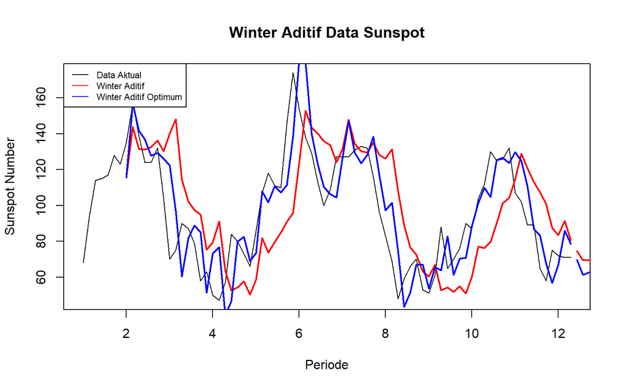

```r
plot(
  training_winter.ts,
  main = "Winter Aditif Data Sunspot",
  type = "l",
  col = "black",
  xlab = "Periode",
  ylab = "Sunspot Number"
)

lines(xhat1, col = "red", lty = 1, lwd = 2)
lines(xhat1.opt, col = "blue", lty = 1, lwd = 2)

# Menampilkan hasil forecast
lines(
  ts(
    forecast1,
    start = tsp(training_winter.ts)[2] + 1/7,
    frequency = 7
  ),
  col = "red",
  lwd = 2
)

lines(
  ts(
    forecast1.opt,
    start = tsp(training_winter.ts)[2] + 1/7,
    frequency = 7
  ),
  col = "blue",
  lwd = 2
)

legend(
  "topleft",
  c("Data Aktual", "Winter Aditif", "Winter Aditif Optimum"),
  col = c("black", "red", "blue"),
  lty = 1,
  cex = 0.7
)
```

Plot di atas membandingkan data aktual dengan garis pemulusan dan ramalan dari model Winter Aditif manual (merah) dan optimum (biru). Semakin dekat garis pemulusan/ramalan mengikuti pola naik-turun data aktual, semakin baik model tersebut menangkap pola musiman pada data.

### Akurasi Data Latih

```r
# Akurasi training Winter Aditif
SSE_winter1 <- winter1$SSE
MSE_winter1 <- SSE_winter1 / length(training_winter.ts)
RMSE_winter1 <- sqrt(MSE_winter1)

SSE_winter1.opt <- winter1.opt$SSE
MSE_winter1.opt <- SSE_winter1.opt / length(training_winter.ts)
RMSE_winter1.opt <- sqrt(MSE_winter1.opt)

akurasi_winter1.train <- data.frame(
  Model = c("Winter Aditif", "Winter Aditif Optimum"),
  SSE = c(SSE_winter1, SSE_winter1.opt),
  MSE = c(MSE_winter1, MSE_winter1.opt),
  RMSE = c(RMSE_winter1, RMSE_winter1.opt)
)

akurasi_winter1.train
```

```
##                   Model      SSE      MSE     RMSE
## 1         Winter Aditif 68240.53 853.0066 29.20628
## 2 Winter Aditif Optimum 24316.47 303.9558 17.43433
```

Pada data latih, model Winter Aditif optimum (alpha=0,8825; beta=0,0153; gamma=1) jauh lebih baik dibandingkan model manual (alpha=0,2; beta=0,1; gamma=0,1): MSE optimum sebesar 303,96 dibandingkan MSE manual sebesar 853,01, dengan RMSE masing-masing 17,43 dan 29,21. Hal ini wajar karena parameter optimum memang dipilih khusus untuk meminimumkan SSE pada data latih.

### Akurasi Data Uji

```r
# Data aktual testing
aktual_winter <- as.numeric(testing_winter$Sunspot)

# Forecast model pertama
ramalan_winter1 <- as.numeric(forecast1)

# Forecast model optimum
ramalan_winter1.opt <- as.numeric(forecast1.opt)

# Error
error_winter1 <- ramalan_winter1 - aktual_winter
error_winter1.opt <- ramalan_winter1.opt - aktual_winter

# Akurasi model pertama
SSEtesting_winter1 <- sum(error_winter1^2)
MSEtesting_winter1 <- mean(error_winter1^2)
RMSEtesting_winter1 <- sqrt(MSEtesting_winter1)

# Akurasi model optimum
SSEtesting_winter1.opt <- sum(error_winter1.opt^2)
MSEtesting_winter1.opt <- mean(error_winter1.opt^2)
RMSEtesting_winter1.opt <- sqrt(MSEtesting_winter1.opt)
```

```r
akurasi_testing_winter1 <- data.frame(
  Model = c("Winter Aditif", "Winter Aditif Optimum"),
  SSE = c(SSEtesting_winter1, SSEtesting_winter1.opt),
  MSE = c(MSEtesting_winter1, MSEtesting_winter1.opt),
  RMSE = c(RMSEtesting_winter1, RMSEtesting_winter1.opt)
)

akurasi_testing_winter1
```

```
##                   Model      SSE      MSE     RMSE
## 1         Winter Aditif 38118.11 1905.906 43.65668
## 2 Winter Aditif Optimum 20328.08 1016.404 31.88109
```

Pada data uji, model optimum tetap unggul dengan MSE=1016,40 (RMSE=31,88) dibandingkan model manual dengan MSE=1905,91 (RMSE=43,66). Meskipun peningkatan error dari data latih ke data uji secara relatif lebih besar pada model optimum (dari MSE 303,96 menjadi 1016,40, naik sekitar 3,3 kali) dibandingkan model manual (dari 853,01 menjadi 1905,91, naik sekitar 2,2 kali) — pola yang biasanya menandakan overfitting — secara nilai absolut model optimum tetap jauh lebih akurat pada data uji. Artinya, di sini pengoptimuman parameter tetap menghasilkan model yang lebih baik untuk generalisasi, meski keunggulannya menyusut dibandingkan pada data latih.

## Winter Multiplikatif

Model multiplikatif digunakan cocok digunakan jika plot data asli menunjukkan fluktuasi musiman yang bervariasi.

### Pemulusan

```r
# Pemulusan Winter Multiplikatif
winter2 <- HoltWinters(
  training_winter.ts,
  alpha = 0.2,
  beta = 0.1,
  gamma = 0.3,
  seasonal = "multiplicative"
)

winter2
```

```
## Holt-Winters exponential smoothing with trend and multiplicative seasonal component.
##
## Call:
## HoltWinters(x = training_winter.ts, alpha = 0.2, beta = 0.1,     gamma = 0.3, seasonal = "multiplicative")
##
## Smoothing parameters:
##  alpha: 0.2
##  beta : 0.1
##  gamma: 0.3
##
## Coefficients:
##          [,1]
## a  77.8782872
## b  -1.7653827
## s1  0.9726677
## s2  0.9076608
## s3  0.9140322
## s4  0.9743446
## s5  0.9038401
## s6  0.9420526
## s7  0.9625144
```

```r
winter2$fitted
```

```
## Time Series:
## Start = c(2, 1)
## End = c(12, 3)
## Frequency = 7
##                xhat     level       trend    season
##  2.000000 115.67946 113.10714  3.00000000 0.9963165
##  2.142857 141.87419 119.98554  3.38783946 1.1499579
##  2.285714 131.43841 126.00405  3.65090665 1.0137554
##  2.428571 131.92640 131.14675  3.80008650 0.9776176
##  2.571429 132.15236 133.32526  3.63792893 0.9648750
##  2.714286 136.07626 135.27337  3.46894618 0.9807842
##  2.857143 129.52596 137.91109  3.38582363 0.9166935
##  3.000000 143.40093 135.72777  2.82890989 1.0349622
##  3.142857 148.26886 124.37241  1.41048263 1.1787680
##  3.285714 116.65115 113.35146  0.16733975 1.0275932
##  3.428571 104.02277 108.33170 -0.35137033 0.9633492
##  3.571429  98.59706 104.44625 -0.70477836 0.9504112
##  3.714286  95.90889  99.61756 -1.11716952 0.9736904
##  3.857143  77.40991  90.71375 -1.89583366 0.8715573
##  4.000000  74.40000  85.51121 -2.22650402 0.8933213
##  4.142857  76.82298  77.82195 -2.77278014 1.0236353
##  4.285714  63.79530  69.22229 -3.35546771 0.9685497
##  4.428571  56.34854  64.46364 -3.49578670 0.9242337
##  4.571429  57.85350  66.95150 -2.89742167 0.9031977
##  4.714286  58.12541  68.95810 -2.40701952 0.8733955
##  4.857143  56.42500  69.95723 -2.06640431 0.8311138
##  5.000000  55.92260  70.19496 -1.83599068 0.8180726
##  5.142857  68.66025  75.71221 -1.10066719 0.9202363
##  5.285714  77.98487  82.94413 -0.26740836 0.9432506
##  5.428571  93.88497  91.16124  0.58104332 1.0233555
##  5.571429  94.10912  95.08717  0.91553186 0.9802758
##  5.714286  92.89047  99.24482  1.23974421 0.9244252
##  5.857143  98.79315 111.97485  2.38877238 0.8638512
##  6.000000 124.13818 131.77561  4.12997170 0.9134149
##  6.142857 151.81743 142.44409  4.78382175 1.0311729
##  6.285714 156.30805 144.54796  4.51582732 1.0485984
##  6.428571 157.69028 143.85530  3.99497871 1.0665538
##  6.571429 145.29463 139.46997  3.15694722 1.0187041
##  6.714286 141.20503 133.73432  2.26768751 1.0382569
##  6.857143 131.55393 129.79833  1.64732034 1.0008237
```

[output cut: 23 more lines]

```
## 10.285714  82.48428  83.43899 -0.08300294 0.9895424
## 10.428571  83.23631  89.32151  0.51354995 0.9265459
## 10.571429  97.08700  99.92926  1.52296967 0.9569726
## 10.714286 109.24392 107.28583  2.10633005 0.9986448
## 10.857143 113.58526 112.74793  2.44190647 0.9860702
## 11.000000 114.43575 118.92481  2.81540393 0.9399996
## 11.142857 124.78644 120.15814  2.65719648 1.0160493
## 11.285714 128.83765 118.33003  2.20866633 1.0688489
## 11.428571 118.99874 113.08439  1.46323537 1.0388582
## 11.571429 111.78694 108.77230  0.88570240 1.0194144
## 11.714286 103.89318 100.47882 -0.03221561 1.0343125
## 11.857143  92.75894  91.57246 -0.91962976 1.0232327
## 12.000000  79.48401  87.18169 -1.26674411 0.9251476
## 12.142857  80.36863  84.29704 -1.42853466 0.9698333
## 12.285714  78.06960  80.93649 -1.62173555 0.9843011
```

```r
xhat2 <- winter2$fitted[, "xhat"]
```

```r
# Winter Multiplikatif dengan parameter optimum
winter2.opt <- HoltWinters(
  training_winter.ts,
  alpha = NULL,
  beta = NULL,
  gamma = NULL,
  seasonal = "multiplicative"
)

winter2.opt
```

```
## Holt-Winters exponential smoothing with trend and multiplicative seasonal component.
##
## Call:
## HoltWinters(x = training_winter.ts, alpha = NULL, beta = NULL,     gamma = NULL, seasonal = "multiplicative")
##
## Smoothing parameters:
##  alpha: 0.9284738
##  beta : 0.01660616
##  gamma: 1
##
## Coefficients:
##          [,1]
## a  68.6821452
## b   0.3328092
## s1  0.9990273
## s2  0.9412529
## s3  0.9516729
## s4  0.9337441
## s5  0.8965580
## s6  1.0172295
## s7  1.0337476
```

```r
# Parameter optimum
winter2.opt$alpha
```

```
##     alpha
## 0.9284738
```

```r
winter2.opt$beta
```

```
##       beta
## 0.01660616
```

```r
winter2.opt$gamma
```

```
## gamma
##     1
```

```r
xhat2.opt <- winter2.opt$fitted[, "xhat"]
```

Nilai alpha, beta, dan gamma optimum di atas dipilih otomatis untuk meminimumkan SSE pada data latih dengan skema musiman multiplikatif.

### Peramalan

```r
# Forecast Winter Multiplikatif
forecast2 <- predict(winter2, n.ahead = h_winter)
forecast2.opt <- predict(winter2.opt, n.ahead = h_winter)

forecast2
```

```
## Time Series:
## Start = c(12, 4)
## End = c(15, 2)
## Frequency = 7
##            fit
##  [1,] 74.03256
##  [2,] 67.48233
##  [3,] 66.34241
##  [4,] 68.99992
##  [5,] 62.41140
##  [6,] 63.38694
##  [7,] 63.06453
##  [8,] 62.01265
##  [9,] 56.26575
## [10,] 55.04710
## [11,] 56.95929
## [12,] 51.24204
## [13,] 51.74536
## [14,] 51.17009
## [15,] 49.99273
## [16,] 45.04917
## [17,] 43.75178
## [18,] 44.91865
## [19,] 40.07267
## [20,] 40.10378
```

```r
forecast2.opt
```

```
## Time Series:
## Start = c(12, 4)
## End = c(15, 2)
## Frequency = 7
##            fit
##  [1,] 68.94782
##  [2,] 65.27378
##  [3,] 66.31312
##  [4,] 65.37458
##  [5,] 63.06944
##  [6,] 71.89676
##  [7,] 73.40829
##  [8,] 71.27522
##  [9,] 67.46659
## [10,] 68.53019
## [11,] 67.54989
## [12,] 65.15812
## [13,] 74.26657
## [14,] 75.81657
## [15,] 73.60262
## [16,] 69.65939
## [17,] 70.74727
## [18,] 69.72520
## [19,] 67.24680
## [20,] 76.63637
```

Hasil ramalan Winter Multiplikatif manual dan optimum di atas dapat dibandingkan langsung dengan hasil ramalan Winter Aditif sebelumnya untuk melihat metode musiman mana yang lebih sesuai dengan pola data sunspot.

### Plot Deret Waktu

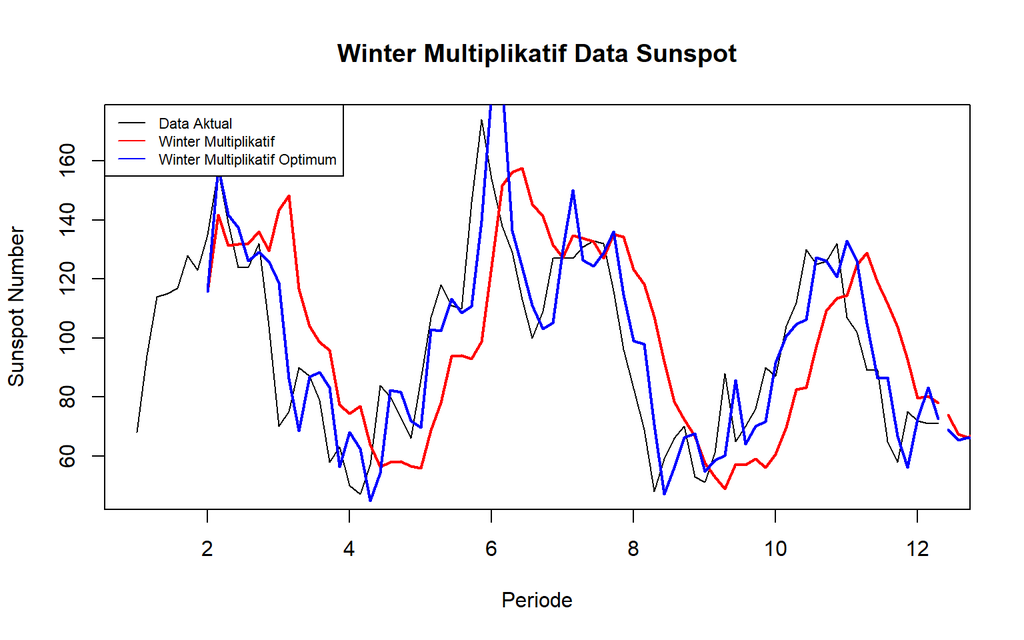

```r
plot(
  training_winter.ts,
  main = "Winter Multiplikatif Data Sunspot",
  type = "l",
  col = "black",
  xlab = "Periode",
  ylab = "Sunspot Number"
)

lines(xhat2, col = "red", lty = 1, lwd = 2)
lines(xhat2.opt, col = "blue", lty = 1, lwd = 2)

lines(
  ts(
    forecast2,
    start = tsp(training_winter.ts)[2] + 1/7,
    frequency = 7
  ),
  col = "red",
  lwd = 2
)

lines(
  ts(
    forecast2.opt,
    start = tsp(training_winter.ts)[2] + 1/7,
    frequency = 7
  ),
  col = "blue",
  lwd = 2
)

legend(
  "topleft",
  c("Data Aktual", "Winter Multiplikatif",
    "Winter Multiplikatif Optimum"),
  col = c("black", "red", "blue"),
  lty = 1,
  cex = 0.7
)
```

Sama seperti pada model aditif, plot ini digunakan untuk menilai secara visual seberapa baik garis pemulusan dan ramalan Winter Multiplikatif mengikuti pola data aktual.

### Akurasi Data Latih

```r
# Akurasi training Winter Multiplikatif
SSE_winter2 <- winter2$SSE
MSE_winter2 <- SSE_winter2 / length(training_winter.ts)
RMSE_winter2 <- sqrt(MSE_winter2)

SSE_winter2.opt <- winter2.opt$SSE
MSE_winter2.opt <- SSE_winter2.opt / length(training_winter.ts)
RMSE_winter2.opt <- sqrt(MSE_winter2.opt)

akurasi_winter2.train <- data.frame(
  Model = c("Winter Multiplikatif",
            "Winter Multiplikatif Optimum"),
  SSE = c(SSE_winter2, SSE_winter2.opt),
  MSE = c(MSE_winter2, MSE_winter2.opt),
  RMSE = c(RMSE_winter2, RMSE_winter2.opt)
)

akurasi_winter2.train
```

```
##                          Model      SSE      MSE     RMSE
## 1         Winter Multiplikatif 66678.11 833.4764 28.86999
## 2 Winter Multiplikatif Optimum 21895.51 273.6939 16.54370
```

Pada data latih, model Winter Multiplikatif optimum (alpha=0,9285; beta=0,0166; gamma=1) memang jauh lebih baik dibandingkan model manual (alpha=0,2; beta=0,1; gamma=0,3): MSE optimum=273,69 (RMSE=16,54) dibandingkan MSE manual=833,48 (RMSE=28,87), sehingga pengoptimuman parameter benar-benar memperbaiki pemulusan pada data latih.

### Akurasi Data Uji

```r
# Forecast
ramalan_winter2 <- as.numeric(forecast2)
ramalan_winter2.opt <- as.numeric(forecast2.opt)

# Error
error_winter2 <- ramalan_winter2 - aktual_winter
error_winter2.opt <- ramalan_winter2.opt - aktual_winter

# Akurasi model multiplikatif
SSEtesting_winter2 <- sum(error_winter2^2)
MSEtesting_winter2 <- mean(error_winter2^2)
RMSEtesting_winter2 <- sqrt(MSEtesting_winter2)

# Akurasi model optimum
SSEtesting_winter2.opt <- sum(error_winter2.opt^2)
MSEtesting_winter2.opt <- mean(error_winter2.opt^2)
RMSEtesting_winter2.opt <- sqrt(MSEtesting_winter2.opt)
```

```r
akurasi_testing_winter2 <- data.frame(
  Model = c("Winter Multiplikatif",
            "Winter Multiplikatif Optimum"),
  SSE = c(SSEtesting_winter2, SSEtesting_winter2.opt),
  MSE = c(MSEtesting_winter2, MSEtesting_winter2.opt),
  RMSE = c(RMSEtesting_winter2, RMSEtesting_winter2.opt)
)

akurasi_testing_winter2
```

```
##                          Model      SSE       MSE     RMSE
## 1         Winter Multiplikatif 40436.44 2021.8221 44.96468
## 2 Winter Multiplikatif Optimum 19331.77  966.5885 31.09001
```

Pada data uji, model Winter Multiplikatif optimum kembali unggul dengan MSE=966,59 (RMSE=31,09) dibandingkan model manual dengan MSE=2021,82 (RMSE=44,96). Nilai MSE model optimum ini bahkan menjadi yang **terbaik kedua** di antara seluruh delapan metode yang dicoba pada tugas ini (lihat perbandingan lengkap di akhir dokumen), hanya kalah dari DMA.

## Perbandingan Winter Aditif dan Multiplikatif

```r
perbandingan_winter <- data.frame(
  Model = c(
    "Winter Aditif",
    "Winter Aditif Optimum",
    "Winter Multiplikatif",
    "Winter Multiplikatif Optimum"
  ),
  SSE = c(
    SSEtesting_winter1,
    SSEtesting_winter1.opt,
    SSEtesting_winter2,
    SSEtesting_winter2.opt
  ),
  MSE = c(
    MSEtesting_winter1,
    MSEtesting_winter1.opt,
    MSEtesting_winter2,
    MSEtesting_winter2.opt
  ),
  RMSE = c(
    RMSEtesting_winter1,
    RMSEtesting_winter1.opt,
    RMSEtesting_winter2,
    RMSEtesting_winter2.opt
  )
)

perbandingan_winter
```

```
##                          Model      SSE       MSE     RMSE
## 1                Winter Aditif 38118.11 1905.9057 43.65668
## 2        Winter Aditif Optimum 20328.08 1016.4039 31.88109
## 3         Winter Multiplikatif 40436.44 2021.8221 44.96468
## 4 Winter Multiplikatif Optimum 19331.77  966.5885 31.09001
```

Dari keempat varian model Winter di atas, urutan performa pada data uji dari yang terbaik adalah: **Winter Multiplikatif Optimum** (MSE=966,59) > Winter Aditif Optimum (MSE=1016,40) > Winter Aditif manual (MSE=1905,91) > Winter Multiplikatif manual (MSE=2021,82). Pola ini menunjukkan bahwa untuk data sunspot ini, faktor yang paling menentukan performa bukanlah pilihan aditif vs multiplikatif (selisih keduanya relatif kecil), melainkan penggunaan parameter yang dioptimalkan — kedua model optimum jauh mengungguli kedua model dengan parameter manual.

# Perbandingan Seluruh Metode

```r
# Perbandingan MSE seluruh metode
MSE_semua <- data.frame(
  Metode = c(
    "SMA",
    "DMA",
    "SES",
    "DES",
    "Winter Aditif",
    "Winter Aditif Optimum",
    "Winter Multiplikatif",
    "Winter Multiplikatif Optimum"
  ),
  MSE = c(
    MSE_test.sma,
    MSE_test.dma,
    MSEtesting1,
    MSEtestingdes1,
    MSEtesting_winter1,
    MSEtesting_winter1.opt,
    MSEtesting_winter2,
    MSEtesting_winter2.opt
  )
)

MSE_semua
```

```
##                         Metode       MSE
## 1                          SMA 1020.8778
## 2                          DMA  847.8840
## 3                          SES 1024.5975
## 4                          DES 5537.2545
## 5                Winter Aditif 1905.9057
## 6        Winter Aditif Optimum 1016.4039
## 7         Winter Multiplikatif 2021.8221
## 8 Winter Multiplikatif Optimum  966.5885
```

Tabel ini merangkum nilai MSE data uji dari seluruh metode pemulusan yang telah dicoba pada data sunspot. Nilai MSE untuk SES dan DES yang diambil di sini (`MSEtesting1`=1024,60 dan `MSEtestingdes1`=5537,25) masing-masing hanya mewakili skenario alpha=0.2 (SES) dan skenario 1/alpha=0.2,beta=0.2 (DES), bukan skenario terbaik dari masing-masing metode. Skenario SES terbaik (alpha=0.7) sebenarnya memberikan MSE=1022,62 (hampir sama, karena ketiga skenario SES memang sangat mirip pada data uji), sedangkan skenario DES terbaik (alpha=0.6, beta=0.3) memberikan MSE=1743,32 — jauh lebih baik daripada 5537,25 yang tercantum di tabel, meski masih kalah dari mayoritas metode lain. Menggunakan MSE terbaik masing-masing pun tidak mengubah kesimpulan akhir di bawah ini: DMA tetap menjadi metode dengan MSE data uji terkecil secara keseluruhan.

```r
# Mengurutkan model berdasarkan MSE terkecil
MSE_semua[order(MSE_semua$MSE), ]
```

```
##                         Metode       MSE
## 2                          DMA  847.8840
## 8 Winter Multiplikatif Optimum  966.5885
## 6        Winter Aditif Optimum 1016.4039
## 1                          SMA 1020.8778
## 3                          SES 1024.5975
## 5                Winter Aditif 1905.9057
## 7         Winter Multiplikatif 2021.8221
## 4                          DES 5537.2545
```

Setelah diurutkan dari MSE terkecil, urutannya adalah: **DMA** (MSE=847,88) sebagai yang terbaik, diikuti Winter Multiplikatif Optimum (966,59), Winter Aditif Optimum (1016,40), SMA (1020,88), SES (1024,60), Winter Aditif manual (1905,91), Winter Multiplikatif manual (2021,82), dan DES sebagai yang terburuk (5537,25). Dengan demikian, **Double Moving Average (DMA, m=3)** menjadi metode yang direkomendasikan sebagai model akhir untuk data sunspot ini, meskipun MAPE data uji-nya sendiri masih tergolong tinggi (53,75%, di atas ambang 50%), sehingga secara umum, seluruh metode pemulusan sederhana yang dicoba pada tugas ini belum memberikan hasil peramalan yang benar-benar akurat untuk 20 hari ke depan data sunspot, kemungkinan karena data mengandung tren yang berubah arah dan fluktuasi harian yang tinggi sehingga sulit diekstrapolasi oleh metode pemulusan klasik.